# Lectures on causal inference and experimental methods

### 5.2.12 Illustration of Neyman Conservative Estimator

An illustration of *how* conservative the conservative estimator of variance really is (numbers in plot are correlations between $Y(1)$ and $Y(0)$.

We confirm that:

1. the estimator is conservative
2. the estimator is more conservative for negative correlations between $Y(0)$ and $Y(1)$ — eg if those cases that do particularly badly in control are the ones that do particularly well in treatment, and
3. with $\tau$ and $V(Y(0))$ fixed, high positive correlations are associated with highest variance.

### 5.2.13 Illustration of Neyman Conservative Estimator

| $\tau$ | $\rho$ | $\sigma^2_{Y(1)}$ | $\Delta$ | $\sigma^2_{\tau}$ | $\widehat{\sigma}^2_{\tau}$ | $\widehat{\sigma}^2_{\tau(\text{Neyman})}$ |
| --- | --- | --- | --- | --- | --- | --- |
| 1.00 | -1.00 | 1.00 | -0.04 | 0.00 | -0.00 | 0.04 |
| 1.00 | -0.67 | 1.00 | -0.03 | 0.01 | 0.01 | 0.04 |
| 1.00 | -0.33 | 1.00 | -0.03 | 0.01 | 0.01 | 0.04 |
| 1.00 | 0.00 | 1.00 | -0.02 | 0.02 | 0.02 | 0.04 |
| 1.00 | 0.33 | 1.00 | -0.01 | 0.03 | 0.03 | 0.04 |
| 1.00 | 0.67 | 1.00 | -0.01 | 0.03 | 0.03 | 0.04 |
| 1.00 | 1.00 | 1.00 | 0.00 | 0.04 | 0.04 | 0.04 |

Here $\rho$ is the unobserved correlation between $Y(1)$ and $Y(0)$; and $\Delta$ is the final term in the sample variance equation that we cannot estimate.

### 5.2.14 Illustration of Neyman Conservative Estimator

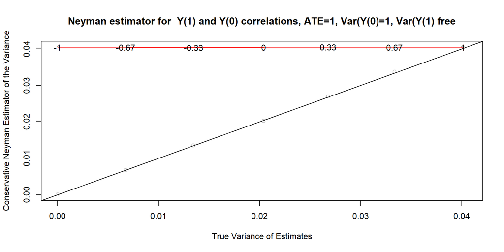

### 5.2.15 Tighter Bounds On Variance Estimate

The conservative variance comes from the fact that you do not know the covariance between $Y(1)$ and $Y(0)$.

- But as [Aronow, Green, and Lee (2014)](http://arxiv.org/pdf/1405.6555.pdf) point out, you *do* know something.
- Intuitively, if you know that the variance of $Y(1)$ is 0, then the covariance also has to be zero.
- This basic insight opens a way of calculating bounds on the variance of the sample average treatment effect.

### 5.2.16 Tighter Bounds On Variance Estimate

Example:

- Take a million-observation dataset, with treatment randomly assigned
- Assume $Y(0)=0$ for everyone and $Y(1)$ distributed normally with mean 0 and standard deviation of 1000.
- Note here the covariance of $Y(1)$ and $Y(0)$ is 0.
- Note the true variance of the estimated sample average treatment effect should be (approx) $\frac{Var(Y(1))}{{1000000}} + \frac{Var(Y(0))}{{1000000}} = 1+0=1$, for an se of $1$.
- But using the Neyman estimator (or OLS!) we estimate (approx) $\frac{Var(Y(1))}{({1000000/2})} + \frac{Var(Y(0))}{({1000000/2})} = 2$, for an se of $\sqrt{2}$.
- But we can recover the truth knowing the covariance between $Y(1)$ and $Y(0)$ is 0.

### 5.2.17 Tighter Bounds On Variance Estimate: Code

```r
sharp_var <- function(yt, yc, N=length(c(yt,yc)), upper=TRUE){

  m <- length(yt)
  n <- m + length(yc)
  V <- function(x,N) (N-1)/(N*(length(x)-1)) * sum((x - mean(x))^2)
  yt <- sort(yt)
  if(upper) {yc <- sort(yc)
  } else {
    yc <- sort(yc,decreasing=TRUE)}
  p_i <- unique(sort(c(seq(0,n-m,1)/(n-m),seq(0,m,1)/m)))-
        .Machine$double.eps^.5
  p_i[1] <- .Machine$double.eps^.5

  yti <- yt[ceiling(p_i*m)]
  yci <- yc[ceiling(p_i*(n-m))]

  p_i_minus <- c(NA,p_i[1: (length(p_i)-1)])

 ((N-m)/m * V(yt,N) + (N-(n-m))/(n-m)*V(yc,N) +
     2*sum(((p_i-p_i_minus)*yti*yci)[2:length(p_i)]) - 2*mean(yt)*mean(yc))/(N-1)}
```

### 5.2.18 Illustration

```r
n   <- 1000000
Y   <- c(rep(0,n/2), 1000*rnorm(n/2))
X   <- c(rep(0,n/2), rep(1, n/2))

lm_robust(Y~X) |> tidy() |> kable(digits = 2)
```

| term | estimate | std.error | statistic | p.value | conf.low | conf.high | df | outcome |
| --- | --- | --- | --- | --- | --- | --- | --- | --- |
| (Intercept) | 0.00 | 0.00 | 0.63 | 0.53 | 0.00 | 0.00 | 999998 | Y |
| X | 1.21 | 1.41 | 0.86 | 0.39 | -1.56 | 3.98 | 999998 | Y |

```r
kable(t(as.matrix(ols)))
```

[output not shown]

```r
c(sharp_var(Y[X==1], Y[X==0], upper = FALSE),
  sharp_var(Y[X==1], Y[X==0], upper = TRUE)) |>
  round(2)
```

```
[1] 1 1
```

The sharp bounds are $[1,1]$ but the conservative estimate is $\sqrt{2}$.

### 5.2.19 Asymptotics

- It is a remarkable thing that you can estimate the standard error straight from the data
- However, once you want to *use* the standard error to do hypothesis testing you generally end up looking up distributions ($t$-distributions or normal distributions)
- That’s a little disappointing and has been one of the criticisms made by Deaton and Cartwright (2018)

However you *can* do hypothesis testing even without an estimate of the standard error.

Up next

## 5.3 Randomization Inference

*A procedure for using the randomization distribution to calculate $p$ values*

### 5.3.1 Calculate a $p$ value in your head

- Illustrating $p$ values via “randomization inference”
- Say you randomized assignment to treatment and your data looked like this.

| Unit | 1 | 2 | 3 | 4 | 5 | 6 | 7 | 8 | 9 | 10 |
| --- | --- | --- | --- | --- | --- | --- | --- | --- | --- | --- |
| Treatment | 0 | 0 | 0 | 0 | 0 | 0 | 0 | 1 | 0 | 0 |
| Health score | 4 | 2 | 3 | 1 | 2 | 3 | 4 | 8 | 7 | 6 |

Then:

- Does the treatment improve your health?
- What’s the $p$ value for the null that treatment had no effect on anybody?

### 5.3.2 Calculate a $p$ value in your head

- Illustrating $p$ values via “randomization inference”
- Say you randomized assignment to treatment and your data looked like this.

| Unit | 1 | 2 | 3 | 4 | 5 | 6 | 7 | 8 | 9 | 10 |
| --- | --- | --- | --- | --- | --- | --- | --- | --- | --- | --- |
| Treatment | 0 | 0 | 0 | 0 | 0 | 0 | 0 | 0 | 1 | 0 |
| Health score | 4 | 2 | 3 | 1 | 2 | 3 | 4 | 8 | 7 | 6 |

Then:

- Does the treatment improve your health?
- What’s the $p$ value for the null that treatment had no effect on anybody?

### 5.3.3 Randomization Inference: Some code

- In principle it is very easy.
- These few lines generate data, produce the regression estimate and then an `ri` estimate of $p$:

```r
# data
set.seed(1)
df <- fabricate(N = 1000, Z = rep(c(0,1), N/2), Y=  .1*Z + rnorm(N))

# test stat
test.stat <- function(df) with(df, mean(Y[Z==1])- mean(Y[Z==0]))

# test stat distribution
ts <- replicate(4000, df |> mutate(Z = sample(Z)) |> test.stat())

# test
mean(ts >= test.stat(df))   # One sided p value
```

```
[1] 0.025
```

### 5.3.4 Randomization Inference: Some code

The $p$ value is the mass to the right of the vertical

```r
hist(ts); abline(v = test.stat(df), col = "red")
```

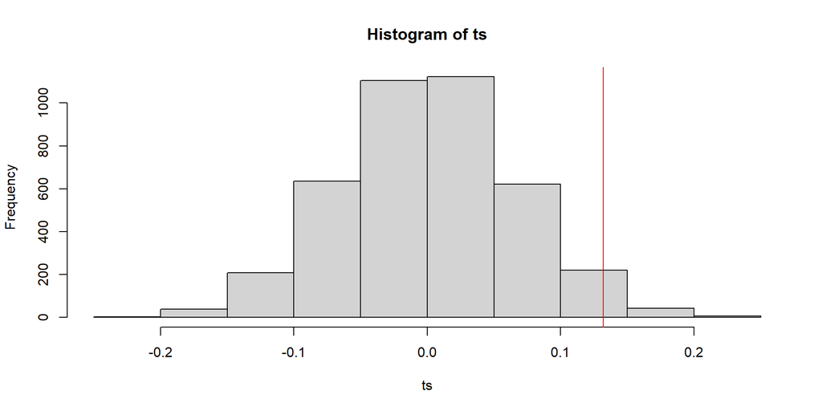

### 5.3.5 Using `ri2`

You can do the same using Alex Coppock’s [ri2](https://cloud.r-project.org/web/packages/ri2/vignettes/ri2_vignette.html) package

```r
library(ri2)

# Declare the assignment
assignment <- declare_ra(N = 1000, m = 500)

# Implement
ri2_out <- conduct_ri(
  formula = Y ~ Z,
  declaration = assignment,
  sharp_hypothesis = 0,
  data = df,
  p = "upper",
  sims = 4000
)
```

### 5.3.6 Using `ri2`

| term | estimate | upper_p_value |
| --- | --- | --- |
| Z | 0.1321367 | 0.02225 |

You’ll notice slightly different answer. This is because although the procedure is “exact” it is subject to simulation error.

### 5.3.7 Randomization Inference

- Randomization inference can get more complicated when you want to test a null other than the sharp null of no effect.
- Say you wanted to test the null that the effect is 2 for all units. How do you do it?
- Say you wanted to test the null that an *interaction effect* is zero. How do you do it?
- In both cases by filling in a potential outcomes schedule given the hypothesis in question and then generating a test statistic

| Observed Y(0) | Observed Y(1) | Under null that effect is 0 Y(0) | Under null that effect is 0 Y(1) | Under null that effect is 2 Y(0) | Under null that effect is 2 Y(1) |
| --- | --- | --- | --- | --- | --- |
| 1 | NA | 1 | 1 | 1 | 3 |
| 2 | NA | 2 | 2 | 2 | 4 |
| NA | 4 | 4 | 4 | 2 | 4 |
| NA | 3 | 3 | 3 | 1 | 3 |

### 5.3.8 `ri` and CIs

It is possible to use this procedure to generate **confidence intervals** with a natural interpretation.

- The key idea is that we can use the same procedure to assess the probability of the data given a sharp null of no effect, but also a sharp null of *any other* **constant* effect.
- We can then see what set of effects we *reject* and what set we *accept*
- We are left with a set of values that *we cannot reject* at the 0.05 level.

### 5.3.9 `ri` and CIs in practice

```r
candidates <- seq(-.05, .3, length = 50)

get_p <- function(j)
  (conduct_ri(
      formula = Y ~ Z,
      declaration = assignment,
      sharp_hypothesis = j,
      data = df,
      sims = 5000,
    ) |> summary()
  )$two_tailed_p_value

# Implement
ps <- candidates |> sapply(get_p)
```

### 5.3.10 `ri` and CIs in practice

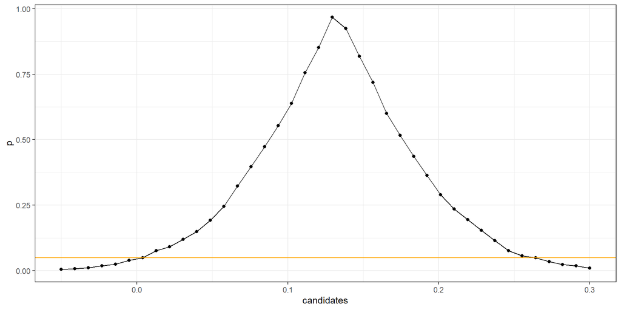

**Warning**: calculating confidence intervals this way can be computationally intensive

### 5.3.11 `ri` with `DeclareDesign`

- `DeclareDesign` can do randomization inference natively.
- The trick is to ensure that the *only* stochastic component is the assignment to treatment when calculating the $p$ values
- (though if you are very careful you can also think through other sources of variability).

```r
set.seed(1)
df <- fabricate(N = 1000, Z = rep(c(0,1), N/2), Y=  .1*Z + rnorm(N))
my_estimate <- with(df, mean(Y[Z==1]) - mean(Y[Z==0]))

design <-
  declare_model(data = df) +
  declare_measurement(Z = sample(Z)) +
  declare_estimator(Y ~ Z)
```

### 5.3.12 `ri` with `DeclareDesign`

```r
ri_ps <-  function(my_estimate)
  declare_diagnosands(
    one_sided_pos = mean(estimate >= my_estimate),
    one_sided_neg = mean(estimate <= my_estimate),
    two_sided = mean(abs(estimate) >= abs(my_estimate)))

diagnose_design(design, sims = 1000, diagnosands = ri_ps(my_estimate))
```

| Design | Estimator | Outcome | Term | N Sims | One Sided Pos | One Sided Neg | Two Sided |
| --- | --- | --- | --- | --- | --- | --- | --- |
| design | estimator | Y | Z | 1000 | 0.02 | 0.98 | 0.04 |
|  |  |  |  |  | (0.00) | (0.00) | (0.01) |

### 5.3.13 `ri` interactions

Lets now imagine a world with two treatments and we are interested in using `ri` for assessing the interaction. (Code from [Coppock, `ri2`](https://cloud.r-project.org/web/packages/ri2/vignettes/ri2_vignette.html))

```r
set.seed(1)

N <- 100
declaration <- randomizr::declare_ra(N = N, m = 50)

data <- fabricate(
  N = N,
  Z = conduct_ra(declaration),
  X = rnorm(N),
  Y = .9 * X + .2 * Z + .1 * X * Z + rnorm(N))
```

### 5.3.14 `ri` interactions

The approach is to declare a null model that is nested by the full model. Then $F$ test statistic from the model comparisons is taken as the test statistic and distribution of this is built up under re-randomizations.

```r
conduct_ri(
    model_1 = Y ~ Z + X,
    model_2 = Y ~ Z + X + Z * X,
    declaration = declaration,
    assignment = "Z",
    sharp_hypothesis = coef(lm(Y ~ Z, data = data))[2],
    data = data,
    sims = 1000
  )  |> summary() |> kable()
```

| term | estimate | two_tailed_p_value |
| --- | --- | --- |
| F-statistic | 1.954396 | 0.171 |

### 5.3.15 `ri` interactions with `DeclareDesign`

Let’s imagine a true model with interactions. We take an estimate. We then ask how likely that estimate is from a *null* model with constant effects

Note: this is *quite* a sharp hypothesis

```r
df <- fabricate(N = 1000, Z1 = rep(c(0,1), N/2), Z2 = sample(Z1), Y = Z1 + Z2 - .15*Z1*Z2 + rnorm(N))

my_estimate <- (lm(Y ~ Z1*Z2, data = df) |> coef())[4]

null_model <-  function(df) {
  M0 <- lm(Y ~ Z1 + Z2, data = df)
  d1 <- coef(M0)[2]
  d2 <- coef(M0)[3]
  df |> mutate(
    Y_Z1_0_Z2_0 = Y - Z1*d1 - Z2*d2,
    Y_Z1_1_Z2_0 = Y + (1-Z1)*d1 - Z2*d2,
    Y_Z1_0_Z2_1 = Y - Z1*d1 + (1-Z2)*d2,
    Y_Z1_1_Z2_1 = Y + (1-Z1)*d1 + (1-Z2)*d2)
  }
```

### 5.3.16 `ri` interactions with `DeclareDesign`

Let’s imagine a true model with interactions. We take an estimate. We then ask how likely that estimate is from a *null* model with constant effects

**Imputed** potential outcomes look like this:

```r
df <- df |> null_model()

df |>  head() |> kable(digits = 2, align = "c")
```

| ID | Z1 | Z2 | Y | Y_Z1_0_Z2_0 | Y_Z1_1_Z2_0 | Y_Z1_0_Z2_1 | Y_Z1_1_Z2_1 |
| --- | --- | --- | --- | --- | --- | --- | --- |
| 0001 | 0 | 0 | -0.18 | -0.18 | 0.76 | 0.68 | 1.61 |
| 0002 | 1 | 0 | 0.20 | -0.73 | 0.20 | 0.12 | 1.06 |
| 0003 | 0 | 0 | 2.56 | 2.56 | 3.50 | 3.42 | 4.36 |
| 0004 | 1 | 0 | -0.27 | -1.21 | -0.27 | -0.35 | 0.59 |
| 0005 | 0 | 1 | -2.13 | -2.99 | -2.05 | -2.13 | -1.19 |
| 0006 | 1 | 1 | 3.52 | 1.72 | 2.66 | 2.58 | 3.52 |

### 5.3.17 `ri` interactions with `DeclareDesign`

```r
design <-
  declare_model(data = df) +
  declare_measurement(Z1 = sample(Z1), Z2 = sample(Z2),
                      Y = reveal_outcomes(Y ~ Z1 + Z2)) +
  declare_estimator(Y ~ Z1*Z2, term = "Z1:Z2")
```

```r
diagnose_design(design, sims = 1000, diagnosands = ri_ps(my_estimate))
```

| Design | Estimator | Outcome | Term | N Sims | One Sided Pos | One Sided Neg | Two Sided |
| --- | --- | --- | --- | --- | --- | --- | --- |
| design | estimator | Y | Z1:Z2 | 1000 | 0.95 | 0.05 | 0.10 |
|  |  |  |  |  | (0.01) | (0.01) | (0.01) |

### 5.3.18 `ri` in practice

- In practice (unless you have a design declaration), it is a good idea to create a $P$ matrix when you do your randomization.
- This records the set of possible randomizations you might have had: or a sample of these.
- So, again: assignments have to be replicable

### 5.3.19 `ri` Applications

- Recall that silly randomization procedure from this slide.
- Say you forgot to take account of the wacky assignment in your estimates and you estimate 0.15.
- *Does the treatment improve your health?*: $p=?$

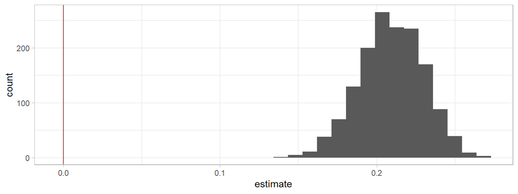

### 5.3.20 `ri` Applications

- Randomization procedures are sometimes funky in lab experiments
- Using randomization inference would force a focus on the true assignment of individuals to treatments
- Fake (but believable) example follows

### 5.3.21 `ri` Applications

|  |  | Capacity | T1 | T2 | T3 |
| --- | --- | --- | --- | --- | --- |
| Session | Thursday | 40 | 10 | 30 | 0 |
|  | Friday | 40 | 10 | 0 | 30 |
|  | Saturday | 10 | 10 | 0 | 0 |

Optimal assignment to treatment given constraints due to facilities

[output not shown]

Constraints due to subjects

### 5.3.22 `ri` Applications

If you think hard about assignment you might come up with an allocation like this.

| Subject type | N | Available | Allocations Thurs | Allocations Fri | Allocations Sat |
| --- | --- | --- | --- | --- | --- |
| A | 30 | Thurs, Fri | 15 | 15 | NA |
| B | 30 | Thurs, Sat | 25 | NA | 5 |
| C | 30 | Fri, Sat | NA | 25 | 5 |

Assignment of people to days

### 5.3.23 `ri` Applications

That allocation balances as much as possible. Given the allocation you might randomly assign individuals to different days as well as randomly assigning them to treatments within days. If you then figure out assignment propensities, this is what you would get:

| Subject type | N | Available | Assignment Probabilities T1 | Assignment Probabilities T2 | Assignment Probabilities T3 |
| --- | --- | --- | --- | --- | --- |
| A | 30 | Thurs, Fri | 0.250 | 0.375 | 0.375 |
| B | 30 | Thurs, Sat | 0.375 | 0.625 | 0.000 |
| C | 30 | Fri, Sat | 0.375 | NA | 0.625 |

### 5.3.24 `ri` Applications

Even under the assumption that the day of measurement does not matter, these assignment probabilities have big implications for analysis.

| Subject type | N | Available | Assignment Probabilities T1 | Assignment Probabilities T2 | Assignment Probabilities T3 |
| --- | --- | --- | --- | --- | --- |
| A | 30 | Thurs, Fri | 0.250 | 0.375 | 0.375 |
| B | 30 | Thurs, Sat | 0.375 | 0.625 | 0.000 |
| C | 30 | Fri, Sat | 0.375 | NA | 0.625 |

### 5.3.25 `ri` Applications

- **Implications for design**: need to uncluster treatment delivery
- **Implications for analysis**: need to take account of propensities

**Idea**: Wacky assignments happen but if you know the propensities you can do the analysis.

### 5.3.26 `ri` Applications: Indirect assignments

A particularly interesting application is where a random assignment combines with existing features to determine an assignment to an “indirect” treatment.

- For instance: $n$ of $N$ are assigned to a treatment.
- You are interested in whether “having a friend assigned to treatment” makes a difference to a subject. Or maybe “a friend of a friend”
- That means the subject has a complex *clustered* assignment that depends on how many friends they have
- A bit mind-boggling, but:
  - Rerun your assignment many times and each time figure out whether a subject is assigned to an indirect treatment or not
  - Calculate the implied quantity of interest for each assignment
  - Assess the place of the actual quantity in the sampling distribution

## 5.4 Covariate Adjustment

### 5.4.1 Example

Consider for example this data.

- You randomly pair offerers and receivers in a dictator game (in which offerers decide how much of $1 to give to receivers).
- Your population comes from two groups (80% Baganda and 20% Banyankole) *so in randomly assigning partners you are randomly determining whether a partner is a coethnic or not*.
- **You find that in non-coethnic pairings 35% is offered, in coethnic pairings 48% is offered.**

Should you believe it?

### 5.4.2 Covariate Adjustment

- Population: randomly matched Baganda (80% of pop) and Banyankole (20% of pop)
- You find: in non-coethnic pairings 35% is offered, in coethnic pairings 48% is offered.
- But a closer look at the data reveals…

|  |  | To: Baganda | To: Banyankole |
| --- | --- | --- | --- |
| Offers by | Baganda | 64% | 16% |
|  | Banyankole | 16% | 4% |

Figure 1: Number of Games

|  |  | To: Baganda | To: Banyankole |
| --- | --- | --- | --- |
| Offers by | Baganda | 50 | 50 |
|  | Banyankole | 20 | 20 |

Figure 2: Average Offers

So that’s a problem

### 5.4.3 Covariate Adjustment

Control?

- With such data you might be tempted to ‘control’ for the covariate (here: ethnic group), using regression.
- But, perhaps surprisingly, it turns out that regression with covariates does not estimate average treatment effects.
- It does estimate an average of treatment effects, but specifically a minimum variance estimator, not necessarily an estimator of your estimand.

### 5.4.4 Covariate Adjustment

Compare:

- $\hat{\tau}_{ATE} =\sum_{x} \frac{w_x}{\sum_{j}w_{j}}\hat{\tau}_x$
- $\hat{\tau}_{OLS} =\sum_{x} \frac{w_xp_x(1-p_x)}{\sum_{j}w_j{p_j(1-p_j)}}\hat{\tau}_x$

Instead you can use formula above for $\hat{\tau}_{ATE}$ to estimate ATE

alternatively…

### 5.4.5 Covariate adjustment via saturated regression

- Alternatively you can use propensity weights.
- Alternatively you can use a regression that includes both the treatment and the treatment *interacted* with the covariates.
  - In practice this is best done by *demeaning* the covariates; doing this lets you read off the average effect from the main term. Key resource: Lin (2012)

You should have noticed that the logic for controlling for a covariate here is equivalent to the logic we saw for heterogeneous assignment propensities. These are really the same thing.

### 5.4.6 Covariate adjustment via saturated regression

Returning to prior example:

```r
df <- fabricatr::fabricate(
  N = 500,
  X = rep(0:1, N/2),
  Z = rbinom(N, 1, .2 + .3*X),
  Y = rnorm(N) + Z*X)

lm_robust(Y ~ Z*X_c, data = df |> mutate(X_c = X - mean(X))) |>
  tidy() |> kable(digits = 2)
```

| term | estimate | std.error | statistic | p.value | conf.low | conf.high | df | outcome |
| --- | --- | --- | --- | --- | --- | --- | --- | --- |
| (Intercept) | -0.02 | 0.06 | -0.42 | 0.68 | -0.14 | 0.09 | 496 | Y |
| Z | 0.59 | 0.10 | 6.05 | 0.00 | 0.40 | 0.78 | 496 | Y |
| X_c | 0.16 | 0.11 | 1.42 | 0.15 | -0.06 | 0.39 | 496 | Y |
| Z:X_c | 0.64 | 0.20 | 3.28 | 0.00 | 0.26 | 1.02 | 496 | Y |

### 5.4.7 Covariate adjustment via saturated regression

Returning to prior example:

```r
lm_lin(Y ~ Z, ~ X, data = df) |>
  tidy() |> kable(digits = 2)
```

| term | estimate | std.error | statistic | p.value | conf.low | conf.high | df | outcome |
| --- | --- | --- | --- | --- | --- | --- | --- | --- |
| (Intercept) | -0.02 | 0.06 | -0.42 | 0.68 | -0.14 | 0.09 | 496 | Y |
| Z | 0.59 | 0.10 | 6.05 | 0.00 | 0.40 | 0.78 | 496 | Y |
| X_c | 0.16 | 0.11 | 1.42 | 0.15 | -0.06 | 0.39 | 496 | Y |
| Z:X_c | 0.64 | 0.20 | 3.28 | 0.00 | 0.26 | 1.02 | 496 | Y |

### 5.4.8 Demeaning and saturating

Demeaning interactions

- Say you have a factorial design with treatments X1 and X2 (or observational data with two covariates)
- You analyse with a model that has main terms and interaction terms
- Interpreting coefficients can be confusing, but sometimes demeaning can help. What does demeaning do?

### 5.4.9 Demeaning and saturating

Let’s:

- Declare a factorial design in which Y is generated according to

`f_Y <- function(X1, X2, u) .1 + .2*X1 + .3*X2 + u*X1*X2`

where u is distributed $U[0,1]$.

- Specify estimands carefully
- Run analyses in which we do and do not demean the treatments; compare and explain results

### 5.4.10 Demeaning interactions

```r
f_Y <- function(X1, X2, u) .1 + .2*X1 + .3*X2 + u*X1*X2

design <-
  declare_model(N = 1000, u = runif(N),
                X1 = complete_ra(N), X2 = block_ra(blocks = X1),
                X1_demeaned = X1 - mean(X1),
                X2_demeaned = X2 - mean(X2),
                Y = f_Y(X1, X2, u)) +
  declare_inquiry(
    base = mean(f_Y(0, 0, u)),
    average = mean(f_Y(0, 0, u) + f_Y(0, 1, u)  + f_Y(1, 0, u)  + f_Y(1, 1, u))/4,
    CATE_X1_given_0 = mean(f_Y(1, 0, u) - f_Y(0, 0, u)),
    CATE_X2_given_0 = mean(f_Y(0, 1, u) - f_Y(0, 0, u)),
    ATE_X1 = mean(f_Y(1, X2, u) - f_Y(0, X2, u)),
    ATE_X2 = mean(f_Y(X1, 1, u) - f_Y(X1, 0, u)),
    I_X1_X2 = mean((f_Y(1, 1, u) - f_Y(0, 1, u)) - (f_Y(1, 0, u) - f_Y(0, 0, u)))
  ) +
  declare_estimator(Y ~ X1*X2,
                    inquiry = c("base", "CATE_X1_given_0", "CATE_X2_given_0", "I_X1_X2"),
                    term = c("(Intercept)", "X1", "X2", "X1:X2"),
                    label = "natural") +
  declare_estimator(Y ~ X1_demeaned*X2_demeaned,
                    inquiry = c("average", "ATE_X1", "ATE_X2", "I_X1_X2"),
                    term = c("(Intercept)", "X1_demeaned", "X2_demeaned", "X1_demeaned:X2_demeaned"),
                    label = "demeaned")
```

### 5.4.11 Demeaning interactions: Solution

| Estimator | Inquiry | Term | Mean Estimand | Mean Estimate |
| --- | --- | --- | --- | --- |
| demeaned | ATE_X1 | X1_demeaned | 0.45 | 0.45 |
| demeaned | ATE_X2 | X2_demeaned | 0.55 | 0.55 |
| demeaned | I_X1_X2 | X1_demeaned:X2_demeaned | 0.50 | 0.50 |
| demeaned | average | (Intercept) | 0.48 | 0.48 |
| natural | CATE_X1_given_0 | X1 | 0.20 | 0.20 |
| natural | CATE_X2_given_0 | X2 | 0.30 | 0.30 |
| natural | I_X1_X2 | X1:X2 | 0.50 | 0.50 |
| natural | base | (Intercept) | 0.10 | 0.10 |

It’s all good. But you need to match the estimator to the inquiry: demean for average marginal effects; do not demean for conditional marginal effects.

### 5.4.12 Recap

If you have different groups with different assignment propensities you can do any or all of these:

1. Blocked differences in means
2. Inverse propensity weighting
3. Saturated regression (Lin)
4. More… (coming)

You cannot (reliably):

1. Ignore the groups
2. Include them in a regression (without interactions)

## 5.5 To control or not control

*When does controlling for covariates improve things and when does it make it worse*

### 5.5.1 Considerations

- Even though randomization ensures no bias, you may sometimes **want** to “**control**” for covariates in order to improve efficiency (see the discussion of blocking above).
- Or you may **have** to take account of the fact that the assignment to treatment is correlated with a covariate (as above).
- In observational work you might also figure out you have to control for a covariate to justify inferences (Refer to our discussion of the backdoor criteria)

### 5.5.2 Observational work

- Observational motivation: Controls can provide grounds for identification
- But recall – they can also destroy identification

For a great walk through of what you can draw from graphical models for the decision to control see:

[A Crash Course in Good and Bad Controls](https://ftp.cs.ucla.edu/pub/stat_ser/r493.pdf) by Cinelli, Forney, and Pearl (2022)

**Aside**: these implications generally refer to use controls as covariates – e.g. by implementing blocked differences in means or similar. For a Bayesian model of the form used in `CausalQueries` the information from “bad controls” is used wisely.

### 5.5.3 Experimental work

- Conditional Bias and Precision Gains from Controls
- Experimental motivation: Controls can reduce noise and improve precision. This is an argument for using variables that are correlated with the output (not with the treatment).

### 5.5.4 Precision Gains from Controls

However: Introducing controls can create complications

- As argued by Freedman (summary from Lin (2012)), we can get: “worsened asymptotic precision, invalid measures of precision, and small-sample bias”$^*$
- These adverse effects are essentially removed with an interacted model
- See discussions in Imbens and Rubin (2015) (7.6, 7.7) and especially Theorem 7.2 for the asymptotic variance of the estimator

$^*$ though note that the precision concern does not hold when treatment and control groups are equally sized

### 5.5.5 To control or not

We will illustrate by comparing:

- DIM
- OLS (linear controls)
- Lin (saturated)

With:

- Varying fraction assigned to treatment
- Varying relation between $Y(0)$ and $Y(1)$

### 5.5.6 Declaration (from RDSS)

```r
# https://book.declaredesign.org/library/experimental-causal.html

prob <- 0.5
control_slope <- -1

declaration_18.3 <-
  declare_model(N = 100, X = runif(N, 0, 1),
                U = rnorm(N, sd = 0.1),
                Y_Z_1 = 1*X + U, Y_Z_0 = control_slope*X + U
  ) +
  declare_inquiry(ATE = mean(Y_Z_1 - Y_Z_0)) +
  declare_assignment(Z = complete_ra(N = N, prob = prob)) +
  declare_measurement(Y = reveal_outcomes(Y ~ Z)) +
  declare_estimator(Y ~ Z, inquiry = "ATE", label = "DIM") +
  declare_estimator(Y ~ Z + X, .method = lm_robust, inquiry = "ATE", label = "OLS") +
  declare_estimator(Y ~ Z, covariates = ~X, .method = lm_lin,
                    inquiry = "ATE", label = "Lin")
```

### 5.5.7 Implied potential outcomes

The variances and covariance of potential outcomes depend on the slope parameter

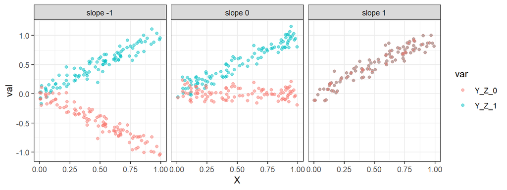

### 5.5.8 To control or not

Diagnosis:

```r
declaration_18.3 |>
  redesign(
    control_slope = seq(-1, 1, 0.5),
    prob = seq(0.1, 0.9, 0.1)) |>
  diagnose_designs()
```

### 5.5.9 To control or not

- Lin always does well
- OLS does fine with equal probability assignments
- Otherwise the ranking of DIM and OLS is design dependent

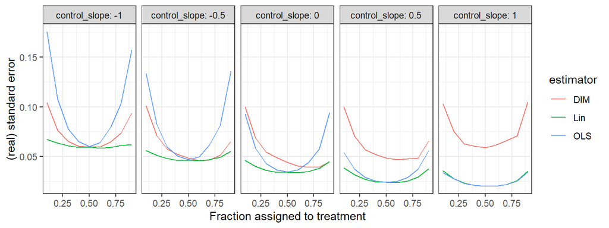

### 5.5.10 Conditional Bias and Precision Gains from Controls

- Treatment correlated with covariates can induce “conditional bias.”
- Including controls that are correlated with treatment can introduce inefficiencies
- Including controls can change your estimates so be sure not to fish!

### 5.5.11 Declaration

```r
a <- 0
b <- 0

design <-
  declare_model(N = 100,
                        X = rnorm(N),
                        Z = complete_ra(N),
                        Y_Z_0 = a*X + rnorm(N),
                        Y_Z_1 = a*X + correlate(given = X, rho = b, rnorm) + 1,
                        Y = reveal_outcomes(Y ~ Z)) +
  declare_inquiry(ATE = mean(Y_Z_1 - Y_Z_0)) +
  declare_estimator(Y ~ Z, covariates = ~X, .method = lm_lin, label = "Lin") +
  declare_estimator(Y ~ Z,  label = "No controls") +
  declare_estimator(Z ~ X,  label = "Condition")
```

The design implements estimation controlling and not controlling for $X$ and also keeps track of the results of a test for the relation between $Z$ and $X$.

### 5.5.12 Simulations

We simulate with many simulations over a range of designs

```r
simulations <-
  list(design |> redesign(a = 0, b = 0),  design |> redesign(a = 1, b = 0),  design |> redesign(a = 0, b = 1)) |>
  simulate_design(sims = 20000)
```

### 5.5.13 Standard errors

We see the standard errors are larger when you control in cases in which the control is *not* predictive of the outcome *and* it *is* correlated with the treatment. Otherwise they can be smaller.

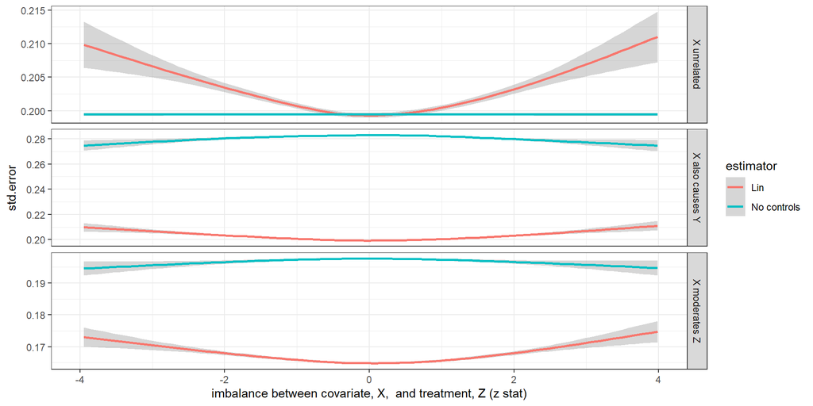

See [Mutz et al](https://www.asc.upenn.edu/sites/default/files/2021-03/The%20perils%20of%20balance%20testing%20in%20experimental%20design-%20Messy%20analyses%20of%20clean%20data.pdf)

### 5.5.14 Errors

We also see “conditional bias” when we do not control: where the distribution of errors depends on the correlation with the covariate.

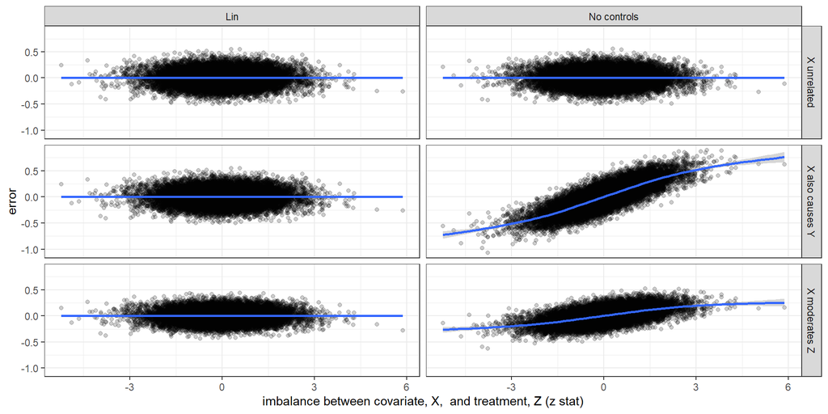

Errors

### 5.5.15 Estimands

Puzzle: Does the sample average treatment effect on the treated depend on the covariate balance?

## 5.6 Doubly robust estimation

### 5.6.1 Doubly robust estimation

Doubly robust estimation combines:

1. A model for how the covariates predict the potential outcomes
2. A model for how the covariates predict assignment propensities

Using both together to estimate potential outcomes using propensity weighting lets you do well even if either model is wrong.

Each part can be done using nonparameteric methods resulting in an overall semi-parametric procedure.

- $\pi(Z) = \Pr(Z=1|X)$: Estimate $\hat\pi$
- $Y_z = \mathbb{E}[Y|Z=z, X]$: Estimate $\hat{Y}_z$
- Estimate of causal effect: $\frac{1}{n}\sum_{i=1}^n\left(\left(\frac{Z_i}{\hat{\pi}_i}(Y_i - \hat{Y}_{i1}\right) - \left(\frac{1-Z_i}{1-\hat{\pi}_i}(Y_i - \hat{Y}_{i0}\right) + \left(\hat{Y}_{i1} - \hat{Y}_{i0}\right) \right)$

### 5.6.2 Doubly robust estimation

- Estimate of causal effect: $\frac{1}{n}\sum_{i=1}^n\left(\left(\frac{Z_i}{\hat{\pi}_i}(Y_i - \hat{Y}_{i1}\right) - \left(\frac{1-Z_i}{1-\hat{\pi}_i}(Y_i - \hat{Y}_{i0}\right) + \left(\hat{Y}_{i1} - \hat{Y}_{i0}\right) \right)$
- Note that if $\hat{Y}_{iz}$ are correct then the first parts drop out and we we get the right answer.
- So if you can impute the potential outcomes, you are good (though hardly surprising)

### 5.6.3 Doubly robust estimation

- More subtly say the $\hat{\pi}$s are correct, but your imputations are wrong; then we again have an unbiased estimator.

To see this imagine with probability $\pi$ we assign unit 1 to treatment and 2 to control (otherwise 1 to control and 2 to treatment).

Then our *expected* estimate is:

$\frac12\pi\left(\left(\frac{1}{\pi}(Y_{11} - \hat{Y}_{11}\right) - \left(\frac{1}{\pi}(Y_{20} - \hat{Y}_{20}\right) \right) + (1-\pi)\left(\left(\frac{1}{1-\pi}(Y_{21} - \hat{Y}_{21}\right) - \left(\frac{1}{1-\pi}(Y_{10} - \hat{Y}_{10}\right) \right) + \left(\hat{Y}_{11} - \hat{Y}_{20}\right) + \left(\hat{Y}_{21} - \hat{Y}_{10}\right)$

$\frac12\left(Y_{11} - Y_{10} + Y_{21}- Y_{20} +\pi\left(\left(\frac{1}{\pi}( - \hat{Y}_{11}\right) - \left(\frac{1}{\pi}( - \hat{Y}_{20}\right) \right) + (1-\pi)\left(\left(\frac{1}{1-\pi}( - \hat{Y}_{21}\right) - \left(\frac{1}{1-\pi}(- \hat{Y}_{10}\right) \right)\right) + \left(\hat{Y}_{11} - \hat{Y}_{20}\right) + \left(\hat{Y}_{21} - \hat{Y}_{10}\right)$

$\frac12\left(Y_{11} - Y_{10} + Y_{21}- Y_{20}\right)$

Robins, Rotnitzky, and Zhao (1994)

### 5.6.4 Doubly robust estimation illustration

Consider this data (with confounding):

```r
# df with true treatment effect of 1
# (0.5 if race = 0; 1.5 if race = 1)

df <- fabricatr::fabricate(
  N = 5000,
  class = sample(1:3, N, replace = TRUE),
  race = rbinom(N, 1, .5),
  Z = rbinom(N, 1, .2 + .3*race),
  Y = .5*Z + race*Z + class + rnorm(N),
  qsmk = factor(Z),
  class = factor(class),
  race = factor(race)
)
```

### 5.6.5 Simple approaches

Naive regression produces biased estimates, even with controls. Lin regression gets the right result however.

```r
# Naive
lm_robust(Y ~ Z, data = df)$coefficients[["Z"]]
```

```
[1] 1.239593
```

```r
# OLS with controls
lm_robust(Y ~ Z + class + race, data = df)$coefficients[["Z"]]
```

```
[1] 1.126977
```

```r
# Lin
lm_lin(Y ~ Z,  ~ class + race, data = df)$coefficients[["Z"]]
```

```
[1] 1.013944
```

### 5.6.6 Doubly robust estimation

`drtmle` is an R package that uses doubly robust estimation to compute “marginal means of an outcome under fixed levels of a treatment.”

```r
library(SuperLearner)
library(drtmle)
drtmle_fit <- drtmle(
  W = df |> select(race, class),
  A = df$Z,
  Y = df$Y,
  SL_Q = c("SL.glm", "SL.mean", "SL.glm.interaction"),
  SL_g = c("SL.glm", "SL.mean", "SL.glm.interaction"),
  SL_Qr = "SL.glm",
  SL_gr = "SL.glm",
  maxIter = 1
)
```

### 5.6.7 Doubly robust estimation

```r
# "Marginal means"
drtmle_fit$drtmle$est
```

```
[1] 2.997512 1.983561
```

```r
# Effects
ci(drtmle_fit, contrast = c(-1,1))
```

```
$drtmle
                   est    cil    ciu
E[Y(0)]-E[Y(1)] -1.014 -1.079 -0.949
```

```r
wald_test(drtmle_fit, contrast = c(-1,1))
```

```
$drtmle
                       zstat pval
H0:E[Y(0)]-E[Y(1)]=0 -30.688    0
```

Resource: https://muse.jhu.edu/article/883477

### 5.6.8 Assessing performance

**Challenge**: Use `DeclareDesign` to compare performance of `drtmle` and `lm_lin`

## 5.7 Principle: Keep the reporting close to the design

### 5.7.1 Design-based analysis

Report the analysis that is implied by the design.

|  |  | T2 |  |  |  |
| --- | --- | --- | --- | --- | --- |
|  |  | N | Y | All | Diff |
| T1 | N | $\overline{y}_{00}$ | $\overline{y}_{01}$ | $\overline{y}_{0x}$ | $d_2\|T1=0$ |
|  |  | (sd) | (sd) | (sd) | (sd) |
|  | Y | $\overline{y}_{10}$ | $\overline{y}_{10}$ | $\overline{y}_{1x}$ | $d_2\|T1=1$ |
|  |  | (sd) | (sd) | (sd) | (sd) |
|  | All | $\overline{y}_{x0}$ | $\overline{y}_{x1}$ | $y$ | $d_2$ |
|  |  | (sd) | (sd) | (sd) | (sd) |
|  | Diff | $d_1\|T2=0$ | $d_1\|T2=1$ | $d_1$ | $d_1d_2$ |
|  |  | (sd) | (sd) | (sd) | (sd) |

This is instantly recognizable from the design and returns all the benefits of the factorial design including all main effects, conditional causal effects, interactions and summary outcomes. It is much clearer and more informative than a regression table.

# 6 Bayesian approaches

*Updating on causal quantities*

## 6.1 Outline

1. Bayesian reasoning
2. Bayesian calculations by hand
3. `stan`
4. A simple structural model with `stan`
5. `CausalQueries`

## 6.2 Bayes reasoning

- Bayesian methods are just sets of procedures to figure out how to update beliefs in light of new information.
- We begin with a prior belief about the probability that a hypothesis is true.
- New data then allow us to form a posterior belief about the probability of the hypothesis.

### 6.2.1 Bayes Rule

Bayesian inference takes into account:

- the consistency of the evidence with a hypothesis
- the uniqueness of the evidence to that hypothesis
- background knowledge about the problem.

### 6.2.2 Illustration 1

I draw a card from a deck and ask *What are the chances it is a Jack of Spades?*

- Just 1 in 52.

Now I tell you that the card is indeed a spade. What would you guess?

- 1 in 13

What if I told you it was a heart?

- No chance it is the Jack of Spades

What if I said it was a face card and a spade.

- 1 in 3.

### 6.2.3 Illustration 1

These answers are applications of Bayes’ rule.

In each case the answer is derived by assessing what is possible, given the new information, and then assessing how likely the outcome of interest among the states that are possible. In all the cases you calculate:

$$\text{Prob Jack of Spades | Info} = \frac{\text{Is Jack of Spades Consistent w/ Info?}}{\text{How many cards are consistent w/ Info?}}$$

### 6.2.4 Illustration 2 **Interpreting Your Test Results**

You take a test to see whether you suffer from a disease that affects 1 in 100 people. The test is good in the following sense:

- if you have the disease, then with a 99% probability it will say you have the disease
- if you do not have it, then with a 99% probability, it will say that you do not have it

The test result says that you have the disease. What are the chances you have it?

### 6.2.5 Illustration 2 **Interpreting Your Test Results**

- It is *not* 99%. 99% is the probability of the result given the disease, but we want the probability of the disease given the result.
- The right answer is 50%, which you can think of as the share of people that have the disease among all those that test positive. For example
- e.g. if there were 10,000 people, then 100 would have the disease and 99 of these would test positive. But 9,900 would not have the disease and 99 of these would test positive. So the people with the disease that test positive are half of the total number testing positive.

### 6.2.6 Illustration 2. A picture

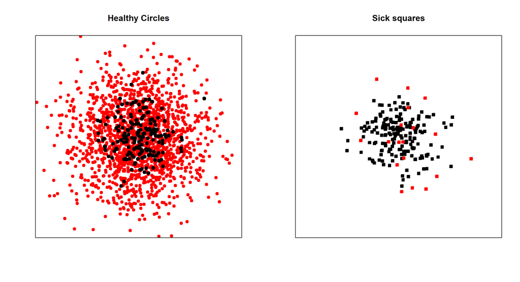

What’s the probability of being a circle given you are black?

### 6.2.7 Illustration 2. More formally.

As an equation this might be written:

$$\text{Prob You have the Disease | Pos} = \frac{\text{How many have the disease and test pos?}}{\text{How many people test pos?}}$$

### 6.2.8 Two Child Problem

Consider last an old puzzle described in Gardner (1961).

- Mr Smith has two children, $A$ and $B$.
- At least one of them is a boy.
- What are the chances they are both boys?

To be explicit about the puzzle, we will assume that the information that one child is a boy is given as a truthful answer to the question “*is at least one of the children a boy?*”

Assuming also that there is a 50% probability that a given child is a boy.

### 6.2.9 Two Child Problem

As an equation:

$$\text{Prob both boys | Not both girls} = \frac{\text{Prob both boys}}{\text{Prob not both girls}} = \frac{\text{1 in 4}}{\text{3 in 4}}$$

### 6.2.10 Monty Hall

Can anyone describe the Monty Hall puzzle?

### 6.2.11 Bayes Rule

Formally, all of these equations are applications of Bayes’ rule which is a simple and powerful formula for deriving updated beliefs from new data.

The formula is given as:

$$\Pr(H|\mathcal{D})=\frac{\Pr(\mathcal{D}|H)\Pr(H)}{\Pr(\mathcal{D})}\\
=\frac{\Pr(\mathcal{D}|H)\Pr(H)}{\sum_{H'}\Pr(\mathcal{D}|H')\Pr(H'))}$$

### 6.2.12 Bayes Rule

Formally, all of these equations are applications of Bayes’ rule which is a simple and powerful formula for deriving updated beliefs from new data.

For continuous distributions and parameter vector $\theta$:

$$p(\theta|\mathcal{D})=\frac{p(\mathcal{D}|\theta)p(\theta)}{\int_{\theta'}p(\mathcal{D|\theta'})p(\theta')d\theta}$$

### 6.2.13 Useful Distributions: Beta and Dirichlet Distributions

- Bayes rule requires the ability to express a prior distribution but it does not require that the prior have any particular properties other than being probability distributions.
- Sometimes however it can be useful to make use of “off the shelf” distributions.

Consider **the share of people in a population that voted**. This is a quantity between 0 and 1.

### 6.2.14 Useful Distributions: Beta and Dirichlet Distributions

- Two people might may both believe that the turnout was around 50% but differ in how certain they are about this claim.
- One might claim to have no information and to believe any turnout rate between 0 and 100% is equally likely; another might be completely confident that the number if 50%.

Here the parameter of interest is a *share*. The **Beta** and **Dirichlet** distributions are particularly useful for representing beliefs on shares.

### 6.2.15 Beta

- The Beta distribution is a distribution over the $[0,1]$ that is governed by two parameters, $\alpha$ and $\beta$.
- In the case in which both $\alpha$ and $\beta$ are 1, the distribution is uniform – all values are seen as equally likely.
- As $\alpha$ rises large outcomes are seen as more likely
- As $\beta$ rises, lower outcomes are seen as more likely.
- If both rise proportionately the expected outcome does not change but the distribution becomes tighter.

An attractive feature is that if one has a prior Beta($\alpha$, $\beta$) over the probability of some event, and then one observes a positive case, the Bayesian posterior distribution is also a Beta with with parameters $\alpha+1, \beta$. Thus if people start with uniform priors and build up knowledge on seeing outcomes, their posterior beliefs should be Beta.

### 6.2.16 Beta

Here is a set of such distributions.

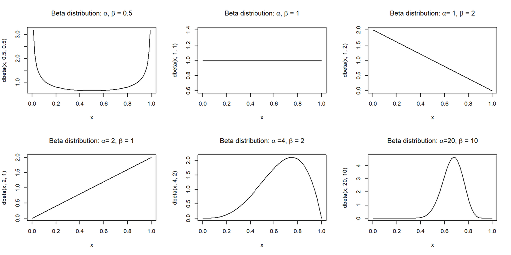

Beta distributions

### 6.2.17 Dirichlet distributions.

The Dirichlet distributions are generalizations of the Beta to the situation in which there are beliefs not just over a proportion, or a probability, but over collections of probabilities.

- If four outcomes are possible and each is likely to occur with probability $p_k$, $k=1,2,3,4$ then beliefs are distributions over a three dimensional unit simplex.
- The distribution has as many parameters as there are outcomes and these are traditionally recorded in a vector, $\alpha$.
- As with the Beta distribution, an uninformative prior (Jeffrey’s prior) has $\alpha$ parameters of $(.5,.5,.5, \dots)$ and a uniform (“flat”) distribution has $\alpha = (1,1,1,,\dots)$.
- The Dirichlet updates in a simple way. If you have a Dirichlet prior with parameter $\alpha = (\alpha_1, \alpha_2, \dots)$ and you observe outcome $1$, for example, then then posterior distribution is also Dirichlet with parameter vector $\alpha' = (\alpha_1+1, \alpha_2,\dots)$.

## 6.3 Bayes by hand

*Bayes on a Grid*

### 6.3.1 Bayes by hand

- The simplest and most intuitive way to do Bayesian estimation is just to apply the formula over a grid of possible values
- This becomes too hard once your parameter space grows but it is worth working though the logic by hand to get a feel for Bayes

### 6.3.2 Bayes by hand

- Lets say that we want to figure out the share of women in some population.
- We start off with a flat prior over all possible numbers
- We draw a sample from the population: 100 people of which 20 are women
- What’s our posterior?

### 6.3.3 Bayes by hand

```r
fabricate(N = 100,
          parameters = seq(.01, .99, length = N),
          likelihood = dbinom(20, 100, parameters),
          posterior = likelihood/sum(likelihood)) |>
  ggplot(aes(parameters, posterior)) + geom_line() + theme_bw()
```

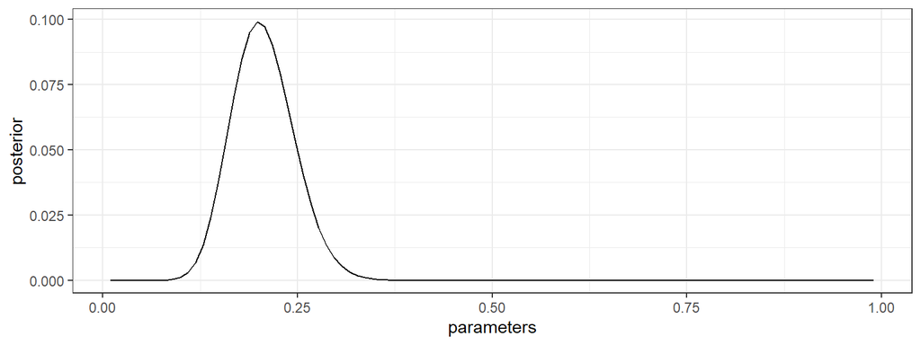

### 6.3.4 Bayes by hand

Now with a strongish prior on 50%:

```r
fabricate(N = 100,
          parameters = seq(.01, .99, length = N),
          prior = dbeta(parameters, 20, 20),
          prior = prior/sum(prior),
          likelihood = dbinom(20, 100, parameters),
          posterior = likelihood*prior/sum(likelihood*prior)) |>
  ggplot(aes(parameters, posterior)) + geom_line() + theme_bw() +
  geom_line(aes(parameters, prior), color = "red")
```

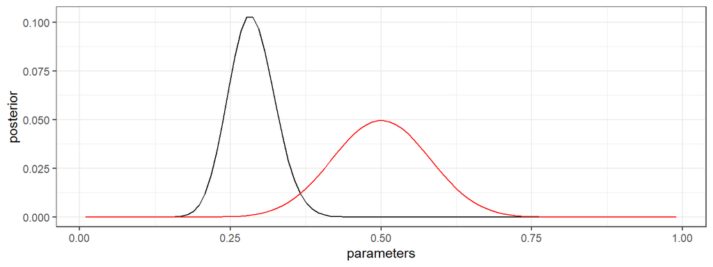

### 6.3.5 Bayes by hand

- This approach is sound, but if you are dealing with many continuous parameters, the full parameter space can get very large and so the number of calculations you do increases rapidly.
- Luckily other approaches have been developed.

## 6.4 Stan

### 6.4.1 Plan

In this short lecture we:

- fire up stan
- implement a simple linear model and talk through the main model blocks
- implement a simple hierarchical model
- describe a behavioral game and set up a model to recover some parameters of interest, given the game

### 6.4.2 Getting set up

The good news: There is lots of help online. Start with: https://github.com/stan-dev/rstan/wiki/RStan-Getting-Started

We will jump straight into things and work through a session.

1. Install the stan package and fire up. Useful to set options so that multiple cores are being used:

```r
library(rstan)
rstan_options(auto_write = TRUE)
options(mc.cores = parallel::detectCores())
```

### 6.4.3 One variable model: Simple example

2. Now lets consider the simplest one var linear model.
   - We will need model code
   - And data

### 6.4.4 A simple model: Code

To implement a stan model you should write the code in a text editor and save it as a text file. You can also write it directly in your script. You can then bring the file into R or call the file directly.

- There are many examples of stan models here:
  - https://github.com/stan-dev/example-models/tree/master/ARM/Ch.4
  - https://github.com/stan-dev/example-models/wiki

### 6.4.5 A simple model: Code

I saved a simple model called `one_var.stan` locally. Here it is:

```r
readLines("assets/one_var.stan", warn = FALSE) |>
  cat(sep = "\n")
```

```
data {
  int<lower=0> N;
  vector[N] Y;
  vector[N] X;
}
parameters {
  real a;
  real b;
  real<lower=0> sigma;
}
model {
  Y ~ normal(a + b * X, sigma);
}
```

### 6.4.6 A simple model: Code

The key features here are (read from bottom up!):

- $Y$ is assumed to be normally distributed with mean `a + bX` and standard deviation `sigma`.
- There are then three parameters: `a`, `b`, `sigma`.
- There are no priors placed on these but sigma is constrained to be positive. Without priors improper flat priors are assumed.
- Stan expects a data set that contains three things: a scalar, `N` and `X1,`Y` data

### 6.4.7 Simple model: Data

We feed data to the model in the form of a list. The idea of a list is that the data can include all sorts of objects, not just a single dataset.

```r
X = rnorm(20)

some_data <- list(
 N = 20,
 X = X,
 Y = X + rnorm(20)
 )
```

### 6.4.8 Simple model: Now Let’s Run It

```r
M <- stan(file = "assets/one_var.stan",
          data = some_data)
```

When you run the model you get a lot of useful output on the estimation and the posterior distribution. Here though are the key results:

|  | mean | sd | Rhat |
| --- | --- | --- | --- |
| a | -0.179 | 0.214 | 1 |
| b | 0.738 | 0.183 | 1 |
| sigma | 0.950 | 0.175 | 1 |

These look good.

The Rhat at the end tells you about convergence. You want this very close to 1.

### 6.4.9 A simple model: Now lets use it

The model output contains the full posterior distribution.

```r
my_posterior <- M |> extract() |> data.frame()

my_posterior |> ggplot(aes(a,b)) + geom_point() + theme_bw()
```

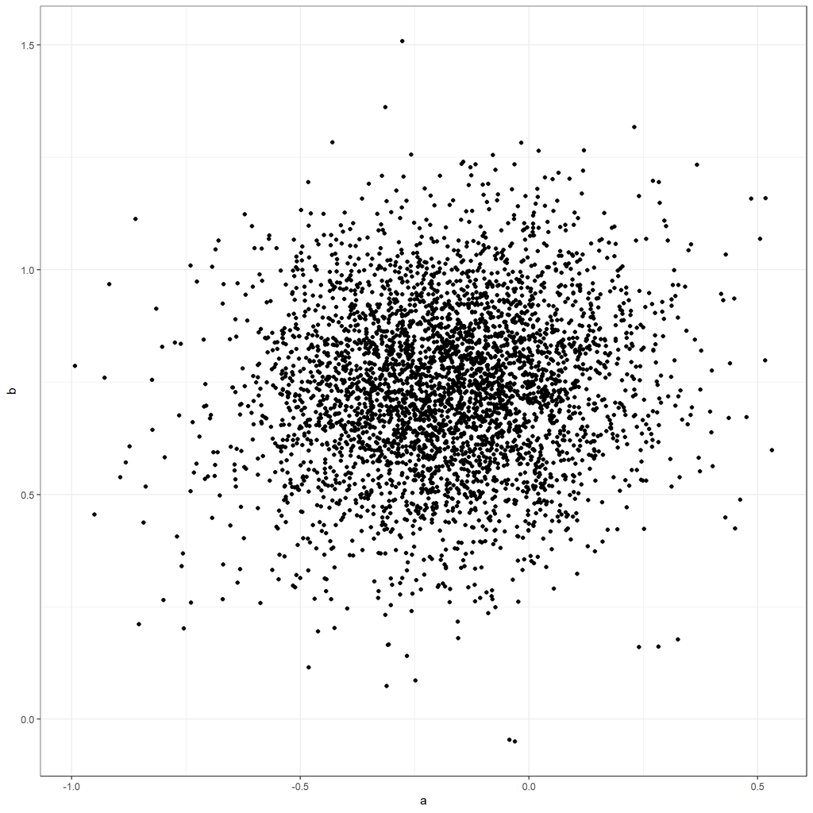

### 6.4.10 A simple model: Now lets use it

With the full posterior you can look at marginal posterior distributions over arbitrary transformations of parameters.

```r
summary((my_posterior$a + my_posterior$b)/my_posterior$a) |> round(2)
```

```
    Min.  1st Qu.   Median     Mean  3rd Qu.     Max.
-2528.86    -3.83    -1.45     0.43    -0.16  6552.41
```

### 6.4.11 Building up

Let’s go back to the code.

There we had three key blocks: `data`, `parameters`, and `model`

More generally the blocks you can specify are:

- `data` (define the vars that will be coming in from the data list)
- `transformed data` (can be used for preprocessing)
- `parameters` (required: defines the parameters to be estimated)
- `transformed parameters` (transformations of parameters useful for computational reasons and sometimes for clarity)
- `model` (give priors and likelihood)
- `generated quantities` (can be used for post processing)

### 6.4.12 Parameters block

The parameters block declared the set of parameters that we wanted to estimate. In the simple model these were `a`, `b`, and `sigma`. Note in the declaration we also:

- said what kind of parameters they (vectors, matrices, simplices etc)
- gave possible constraints

### 6.4.13 Parameters block

Instead of defining:

```r
real a;
real b;
```

We could have defined

```r
vector[2] coefs;
```

and then referenced `coef[1]` and `coef[2]` in the model block.

### 6.4.14 Parameters block

Or we could also have imposed the constraint that the slope coefficient is positive by defining:

```r
real a;
real<lower = 0> b;
```

### 6.4.15 Model Block

In the model block we give the likelihood

But we can also give the priors (if we want to). If priors are not provided, flat (possibly improper) priors are assumed

In our case for example we could have provided something like

```r
model {
  b ~ normal(-10, 1);
  Y ~ normal(a + b * X, sigma);
}
```

This suggests that we start off believing `b` is centered on -10. That will surely matter for our conclusions. Lets try it:

### 6.4.16 Version 2

This time I will write the model right in the editor:

```r
new_model <- '
data {
  int<lower=0> N;
  vector[N] Y;
  vector[N] X;
}
parameters {
  real a;
  real b;
  real<lower=0> sigma;
}
model {
  b ~ normal(-10,1);
  Y ~ normal(a + b * X, sigma);
}
'
```

### 6.4.17 Estimation 2

```r
M2 <- stan(model_code = new_model, data = some_data)
```

|  | mean | sd | Rhat |
| --- | --- | --- | --- |
| a | -1.338 | 2.444 | 1.003 |
| b | -7.875 | 1.172 | 1.003 |
| sigma | 10.988 | 2.499 | 1.001 |

Note that we get a much lower estimate for `b` with the same data.

### 6.4.18 A multilevel model

- Now imagine a setting in which there are 10 villages, each with 10 respondents. Half in each village are assigned to treatment $X=1$, and half to control $X=0$.
- Say that there is possibly a village specific average outcome: $Y_v = a_v + b_vX$ where $a_v$ and $b_v$ are each drawn from some distribution with a mean and variance of interest. The individual outcomes are draws from a village level distribution centered on the village specific average outcome.
- This all implies a multilevel structure.

### 6.4.19 A multilevel model

Here is a model for this

```r
ml_model <- '
data {
  vector[100] Y;
  int<lower=0,upper=1> X[100];
  int village[100];
}
parameters {
  vector<lower=0>[3] sigma;
  vector[10] a;
  vector[10] b;
  real mu_a;
  real mu_b;
}
transformed parameters {
  vector[100] Y_vx;
  for (i in 1:100) Y_vx[i] = a[village[i]] + b[village[i]] * X[i];
}
model {
  a ~ normal(mu_a, sigma[1]);
  b ~ normal(mu_b, sigma[2]);
  Y ~ normal(Y_vx, sigma[3]);
}
'
```

### 6.4.20 A multilevel model

Here is a slightly more general version: https://github.com/stan-dev/example-models/blob/master/ARM/Ch.17/17.1_radon_vary_inter_slope.stan

### 6.4.21 Multilevel model: Data

Lets create some multilevel data. Looking at this, can you tell what is the typical village level effect? How much heterogeneity is there?

```r
village   <- rep(1:10, each = 10)
village_b <- 1 + rnorm(10)
X         <- rep(0:1, 50)
Y         <- village_b[village]*X + rnorm(100)

ml_data <- list(
  village = village,
  X = X,
  Y = Y)
```

### 6.4.22 Multilevel Results

```r
M_ml <- stan(model_code = ml_model, data = ml_data)
```

|  | mean | sd | Rhat |
| --- | --- | --- | --- |
| mu_a | -0.29 | 0.25 | 1.00 |
| mu_b | 1.89 | 0.26 | 1.00 |
| sigma[1] | 0.61 | 0.25 | 1.00 |
| sigma[2] | 0.47 | 0.28 | 1.01 |
| sigma[3] | 0.98 | 0.08 | 1.00 |

## 6.5 A game and a structural model

*parameters drawn from theory*

### 6.5.1 A game and a structural model

Say that a set of people in a population are playing sequential prisoner’s dilemmas.

In such games selfish behavior might suggest defections by everyone everywhere. But of course people often cooperate. Why might this be?

- One possible reason is that some people are irrational, in the sense that they simply choose to cooperate, ignoring the payoffs.
- Another possibility is that rational people think that others are irrational, in the sense that they think that others will reciprocate when they observe cooperative action

### 6.5.3 Expectations from model

- In all, this means that a player with propensity $r_i>.5$ will cooperate with probability $1-r_i$; a player with propensity $r_i<.5$ will cooperate with probability $1$.
- Interestingly the not-very-rational people sometimes cooperate strategically but the really rational people never cooperate strategically because they think it won’t work.

### 6.5.4 Event Probabilities

What then are the probabilities of each of the possible outcomes?

- There will be cooperation by *both* players with probability $(\int_0^{.5} p(r_i) dr_i + \int_{.5}^1 p(r_i)(1-r_i) dr_i)\int_0^1p(r_i)(1-r_i)dr_i$
- There will be cooperation by player 1 only with probability $(\int_0^{.5} p(r_i) dr_i + \int_{.5}^1 p(r_i)(1-r_i) dr_i)(\int_0^1p(r_i)(r_i)dr_i)$
- There will be cooperation by neither with probability: $1-\int_0^{.5} p(r_i) dr_i - \int_{.5}^1 p(r_i)(1-r_i) dr_i$

where $p$ is the density function on $r_i$ given $\theta$

### 6.5.5 Event probabilities

Given the assumption on $p$

### 6.5.6 Data

- We have data on the actions of the first movers and the second movers and are interested in the distribution of the $p_i$s.
- Lets collapse that data into a simple list of the number of each type of game outcome:
- And say we start off with a uniform prior of $\theta$.
- What should we conclude about $\theta$?

### 6.5.7 Model

Here’s a model:

```r
game_model <- '
data {
  int<lower=0> play[3];
}
parameters {
  real<lower=.5, upper=1> theta;
}
transformed parameters {
simplex[3] w;
 w[1] = (1+.25*theta - .5*theta)*(1-.5*theta);
 w[2] = (1+.25*theta - .5*theta)*(.5*theta);
 w[3] = (-.25*theta  + .5*theta);
}
model {
  play ~ multinomial(w);
}
'
```

### 6.5.8 Model

Note we define event weights as transformed parameters on a simplex. We also constrain $\theta$ to be $>.5$. Obviously we are relying *a lot* on our model.

### 6.5.9 Plot posterior on $\theta$

```r
M3 <- stan(model_code = game_model,
           data = list(play = c(10,10,10)))
```

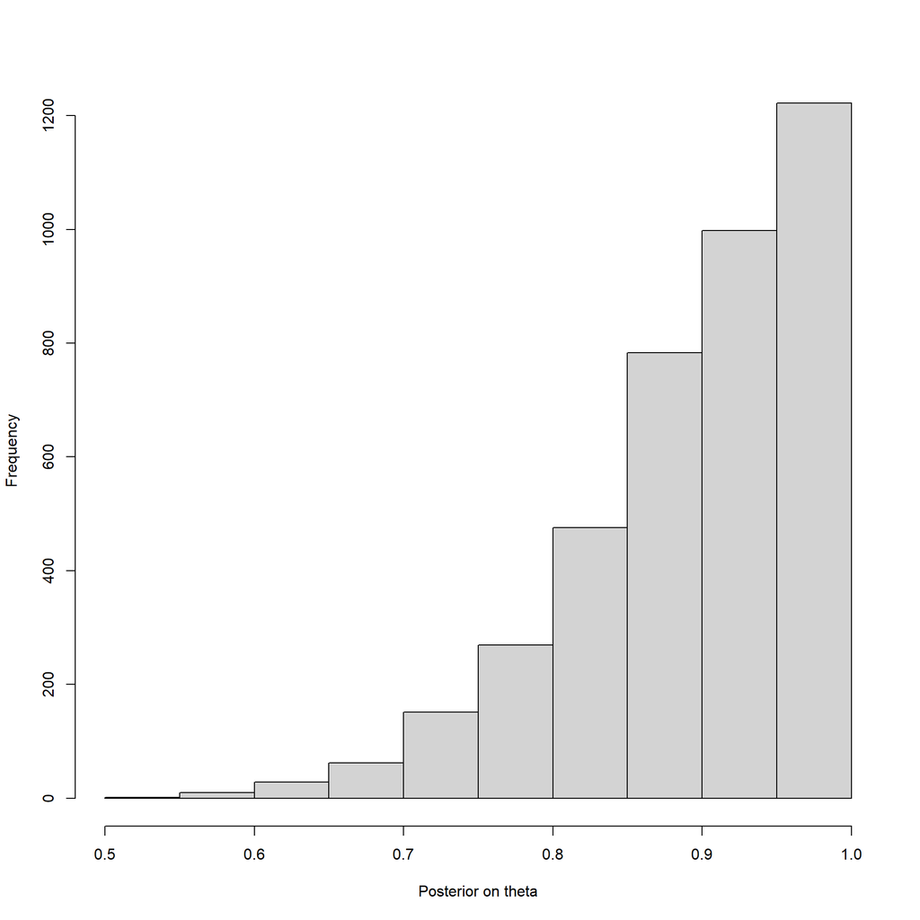

### 6.5.10 Plot posterior on $\theta$

```r
M4 <- stan(model_code = game_model,
           data = list(play = c(20,6,4)))
```

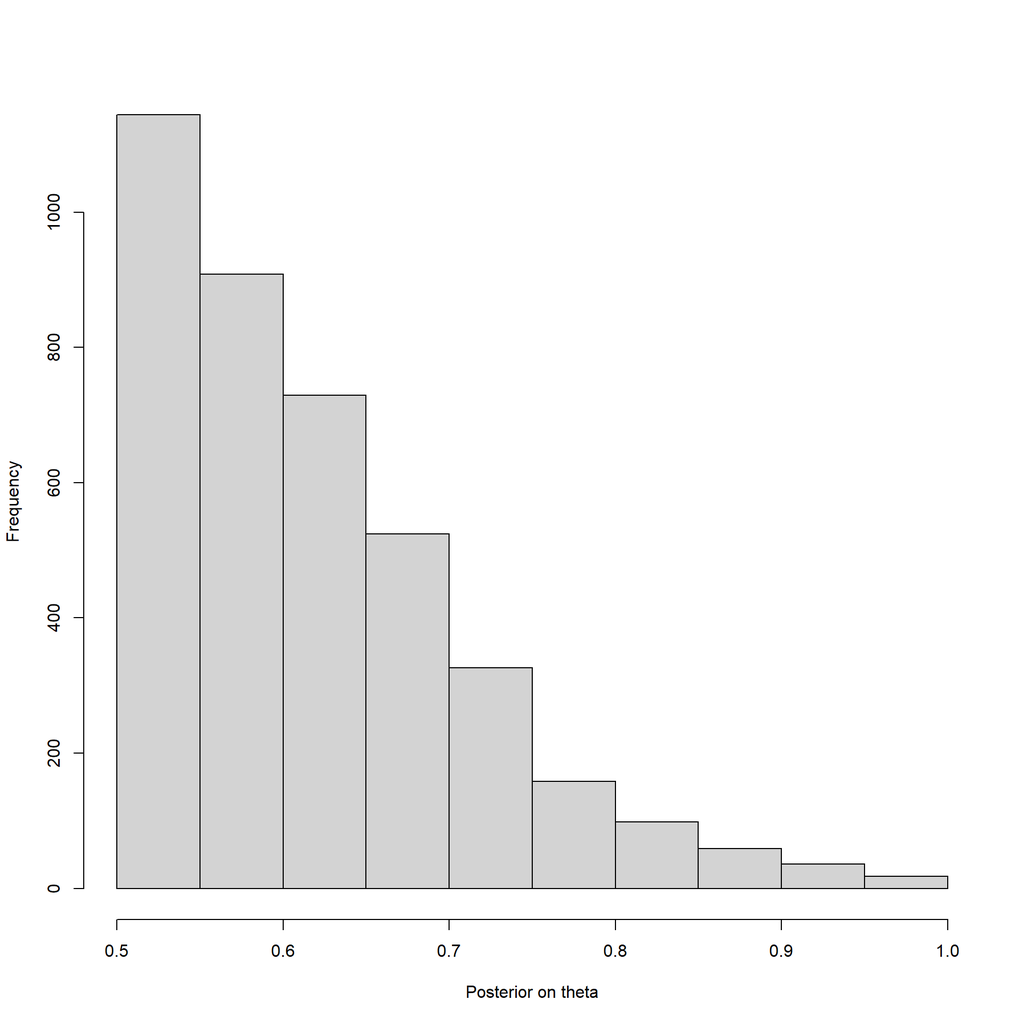

### 6.5.11 Posterior on a quantity of interest

What is the probability of observing *strategic* first round cooperation?

A player with rationality $r_i$ will cooperate strategically with probability $r_i$ if $r_i<.5$ and 0 otherwise. Thus we are interested in $\int_0^{.5}r_i/\theta dr_i = .125/\theta$

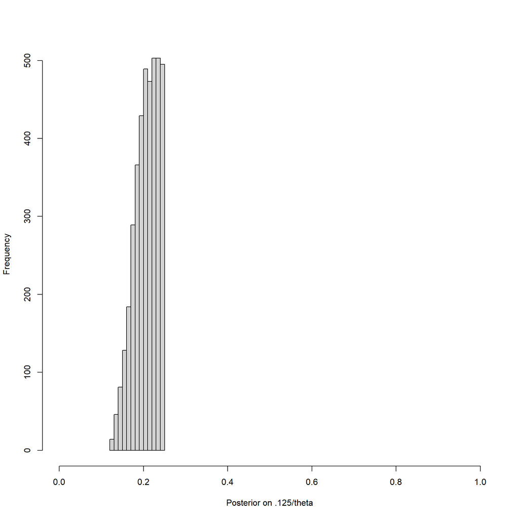

## 6.6 `CausalQueries`

*`CausalQueries` brings these elements together*

### 6.6.1 Big picture

`CausalQueries` brings these elements together by allowing users to:

1. Specify a DAG: `CausalQueries` figures out all principal strata and places a prior on these
2. Provide data to the DAG: `CausalQueries` writes a stand model and updates on all parameters
3. Query model: `CausalQueries` figures out which parameters correspond to a given causal query

### 6.6.2 Illustration: “Lipids” data

```r
data("lipids_data")

lipids_data |> kable()
```

| event | strategy | count |
| --- | --- | --- |
| Z0X0Y0 | ZXY | 158 |
| Z1X0Y0 | ZXY | 52 |
| Z0X1Y0 | ZXY | 0 |
| Z1X1Y0 | ZXY | 23 |
| Z0X0Y1 | ZXY | 14 |
| Z1X0Y1 | ZXY | 12 |
| Z0X1Y1 | ZXY | 0 |
| Z1X1Y1 | ZXY | 78 |

Note that in compact form we simply record the number of units (“count”) that display each possible pattern of outcomes on the three variables (“event”).[^1]

### 6.6.3 Model

```r
model <- make_model("Z -> X -> Y; X <-> Y")
model |> plot()
```

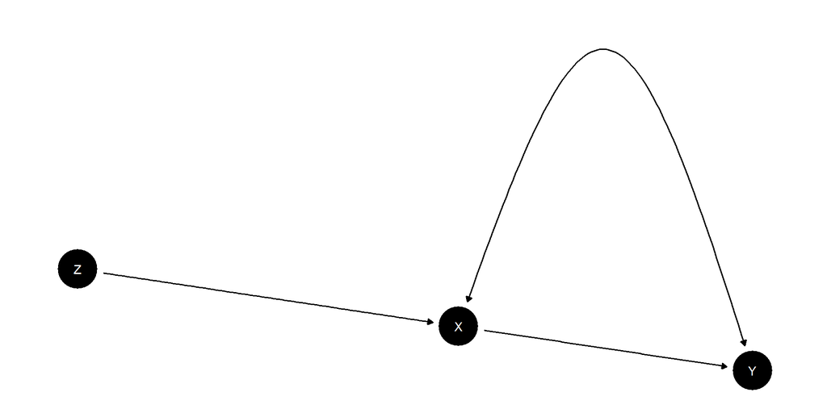

### 6.6.4 Updating and querying

```r
model |>
  update_model(lipids_data, refresh = 0) |>
  query_model(query = "Y[X=1] - Y[X=0]",
              given = c("All",  "X==0 & Y==0", "X[Z=1] > X[Z=0]"),
              using = "posteriors")
```

Table 5: Replication of Chickering and Pearl (1996).

| query | given | mean | sd | cred.low.2.5% | cred.high.97.5% |
| --- | --- | --- | --- | --- | --- |
| Y[X=1] - Y[X=0] | - | 0.55 | 0.10 | 0.37 | 0.73 |
| Y[X=1] - Y[X=0] | X==0 & Y==0 | 0.64 | 0.15 | 0.37 | 0.89 |
| Y[X=1] - Y[X=0] | X[Z=1] > X[Z=0] | 0.70 | 0.05 | 0.59 | 0.80 |

# 7 Design

*Focus on randomization schemes*

## 7.1 Aims and practice

1. Goals
2. Cluster randomization
3. Blocked randomization
4. Factorial designs
5. External validity
6. Assignments with `DeclareDesign`
7. Indirect assignments

### 7.1.1 Experiments

- Experiments are investigations in which an intervention, in all its essential elements, is under the control of the investigator. (Cox & Reid)
- Two major types of control:
1. control over assignment to treatment – this is at the heart of many field experiments
2. control over the treatment itself – this is at the heart of many lab experiments
- Main focus today is on 1 and on the question: *how does control over assignment to treatment allow you to make reasonable statements about causal effects?*

### 7.1.2 Experiments

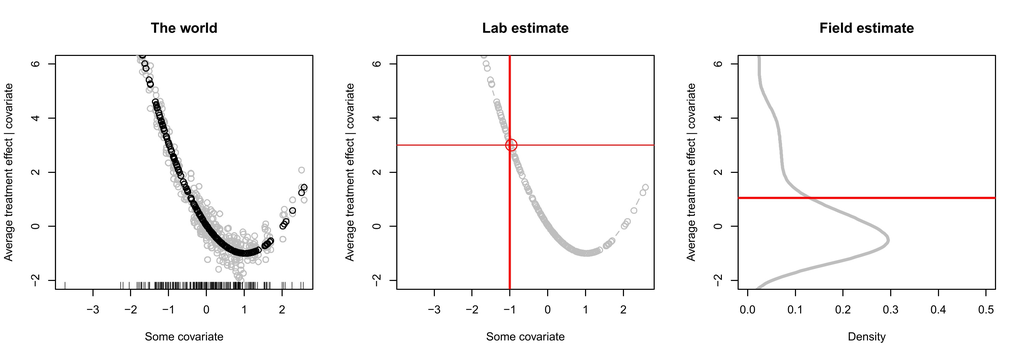

### 7.1.3 Basic randomization

- Basic randomization is very simple. For example, say you want to assign 5 of 10 units to treatment. Here is simple code:

```r
sample(0:1, 10, replace = TRUE)
```

```
 [1] 0 1 0 1 1 1 1 1 1 0
```

### 7.1.4 …should be replicable

In general you might want to set things up so that your randomization is **replicable**. You can do this by setting a **seed**:

```r
set.seed(20111112)
sample(0:1, 10, replace = TRUE)
```

```
 [1] 1 0 1 1 1 0 1 1 1 1
```

and again:

```r
set.seed(20111112)
sample(0:1, 10, replace = TRUE)
```

```
 [1] 1 0 1 1 1 0 1 1 1 1
```

### 7.1.5 Basic randomization

Even better is to set it up so that it can reproduce **lots of possible draws** so that you can check the propensities for each unit.

```r
set.seed(20111112)
P <- replicate(1000, sample(0:1, 10, replace = TRUE))
apply(P, 1, mean)
```

```
 [1] 0.519 0.496 0.510 0.491 0.524 0.514 0.535 0.497 0.470 0.506
```

Here the $P$ matrix gives 1000 possible ways of allocating 5 of 10 units to treatment. We can then confirm that the average propensity is 0.5.

- A huge advantage of this approach is that if you make a mess of the random assignment; **you can still generate the P matrix and use that for all analyses**!

### 7.1.6 Do it in advance

- Unless you need them to keep subjects at ease, leave your spinners and your dice and your cards behind.
- Especially when you have multiple or complex randomizations you are generally much better doing it with a computer in advance

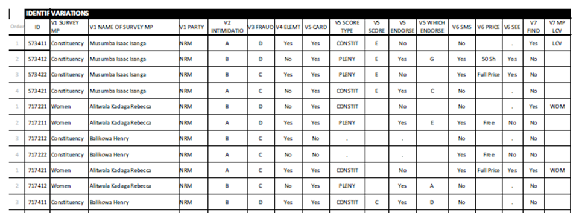

A survey dictionary with results from a complex randomization presented in a simple way for enumerators

### 7.1.7 Did the randomization ‘’work’’?

- People often wonder: did randomization work? Common practice is to implement a set of $t$-tests to see if there is balance. This makes no sense.
- If you doubt whether it was **implemented** properly do an $F$ test. If you worry about **variance**, specify controls in advance as a function of relation with outcomes (more on this later). If you worry about **conditional bias** then look at substantive differences between groups, not $t$–tests
- If you want realizations to have particular properties: *build it into the scheme in advance*.

## 7.2 Cluster Randomization

### 7.2.1 Cluster Randomization

- Simply place units into groups (clusters) and then randomly assign the groups to treatment and control.
- All units in a given group get the same treatment

**Note:** clusters are part of your design, not part of the world.

### 7.2.2 Cluster Randomization

- Often used if intervention has to function at the cluster level *or* if outcome defined at the cluster level.
- *Disadvantage:* loss of statistical power
- However: perfectly possible to assign *some* treatments at cluster level and then *other* treatments at the individual level
- **Principle:** (unless you are worried about spillovers) generally make clusters as small as possible
- **Principle:** Surprisingly, variability in cluster size makes analysis harder. Try to control assignment so that cluster sizes are similar in treatment and in control.
- **Be clear** about whether you believe effects are operating at the cluster level or at the individual level. This matters for power calculations.
- **Be clear** about whether spillover effects operate only within clusters or also across them. If within only you might be able to interpret treatment as the effect of being in a treated cluster…

### 7.2.3 Cluster Randomization: Block by cluster size

Surprisingly, if clusters are of different sizes the difference in means estimator is *not* unbiased, even if all units are assigned to treatment with the same probability.

**Here’s the intuition.**Say there are two clusters each with homogeneous treatment effects:

| Cluster | Size | Y0 | Y1 |
| --- | --- | --- | --- |
| 1 | 1000000 | 0 | 1 |
| 2 | 1 | 0 | 0 |

Then: *What is the true average treatment effect?* What do you expect to estimate from cluster random assignment?

The solution is to block by cluster size. For more see: http://gking.harvard.edu/files/cluster.pdf

## 7.3 Blocked assignments and other restricted randomizations

### 7.3.1 Blocking

There are more or less **efficient** ways to randomize.

- Randomization helps ensure good balance on all covariates (observed and unobserved) *in expectation*.
- But balance may not be so great *in realization*
- Blocking can help ensure balance ex post on observables

### 7.3.2 Blocking

Consider a case with four units and two strata. There are 6 possible assignments of 2 units to treatment:

| ID | X | Y(0) | Y(1) | R1 | R2 | R3 | R4 | R5 | R6 |
| --- | --- | --- | --- | --- | --- | --- | --- | --- | --- |
| 1 | 1 | 0 | 1 | 1 | 1 | 1 | 0 | 0 | 0 |
| 2 | 1 | 0 | 1 | 1 | 0 | 0 | 1 | 1 | 0 |
| 3 | 2 | 1 | 2 | 0 | 1 | 0 | 1 | 0 | 1 |
| 4 | 2 | 1 | 2 | 0 | 0 | 1 | 0 | 1 | 1 |
| – | – | – | – | – | – | – | – | – | – |
| $\widehat{\tau}$: |  |  |  | 0 | 1 | 1 | 1 | 1 | 2 |

Even with a constant treatment effect and everything uniform within blocks, there is variance in the estimation of $\widehat{\tau}$. This can be eliminated by excluding R1 and R6.

### 7.3.3 Blocking

Simple blocking in R (5 pairs):

```r
sapply(1:5, function(i) sample(0:1))
```

| 1 | 2 | 3 | 4 | 5 |
| --- | --- | --- | --- | --- |
| 1 | 1 | 0 | 1 | 1 |
| 0 | 0 | 1 | 0 | 0 |

### 7.3.4 Of blocks and clusters

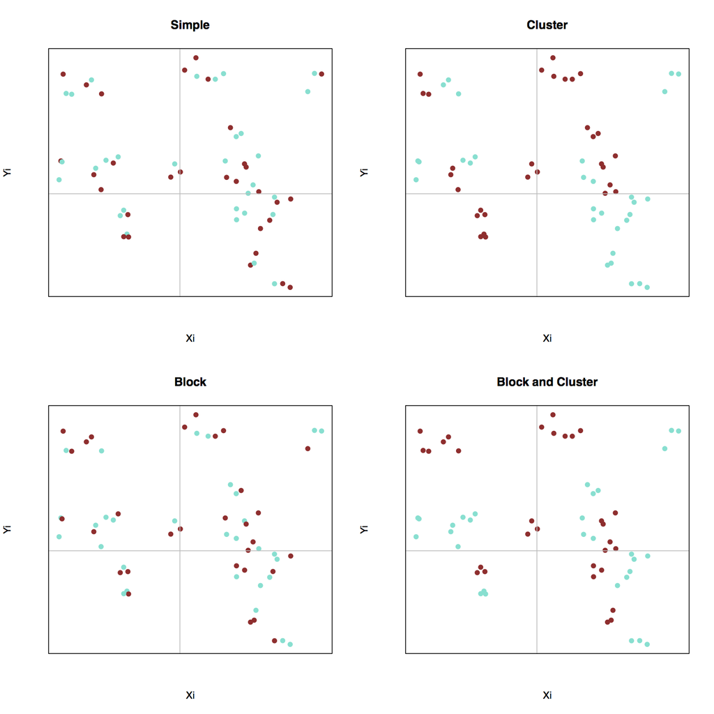

### 7.3.5 Blocking

- Blocking is a case of **restricted randomization**. Although each unit is sampled with equal probability, the *profiles* of possible assignments are not.
- You have to take account of this when doing analysis
- There are many other approaches.
  - **Matched Pairs** are a particularly fine approach to blocking
  - You could also randomize and then **replace the randomization** if you do not like the balance. This sounds tricky (and it is) but it is OK as long as you understand the true lottery process you are employing and incorporate that into analysis
  - It is even possible to block on **covariates for which you don’t have data** ex ante, by using methods in which you allocate treatment over time as a function of features of your sample (also tricky)

### 7.3.6 Other types of restricted randomization

- Really you can set whatever criterion you want for your set of treated units to have (eg no treated unit beside another treated unit; at least 5 from the north, 10 from the south, guaranteed balance by some continuous variable etc)
- You just have to be sure that you understand the random process that was used and that you can use it in the analysis stage
- But here be dragons
  - The more complex your design, the more complex your analysis.
  - General injunction http://www.ncbi.nlm.nih.gov/pubmed/15580598 ``as ye randomize so shall ye analyze’’)
  - In general you should make sure that a given randomization procedure coupled with a given estimation procedure will produce an unbiased estimate. `DeclareDesign` can help with this.

### 7.3.7 Challenges with re-randomization

- We can see that blocked and clustered assignments are actually types of restricted randomizations: they limit the set of acceptable randomizations to those with good properties
- You could therefore implement the *equivalent* distribution of assignments y specifying an acceptable rule and then re-randomizing when the rule is met
- That’s fine *but* you would then have to take account of clustering and blocking just as you do when you actually cluster or block

## 7.4 Factorial Designs

### 7.4.1 Factorial Designs

- Often when you set up an experiment you want to look at more than one treatment.
- Should you do this or not? How should you use your power?

### 7.4.2 Factorial Designs

- Often when you set up an experiment you want to look at more than one treatment.
- Should you do this or not? How should you use your power?

Load up:

|  | $T2=0$ | $T2=1$ |
| --- | --- | --- |
| T1 = 0 | $50\%$ | $0\%$ |
| T1 = 1 | $50\%$ | $0\%$ |

Spread out:

|  | $T2=0$ | $T2=1$ |
| --- | --- | --- |
| T1 = 0 | $25\%$ | $25\%$ |
| T1 = 1 | $25\%$ | $25\%$ |

### 7.4.3 Factorial Designs

- Often when you set up an experiment you want to look at more than one treatment.
- Should you do this or not? How should you use your power?

Three arm it?:

|  | $T2=0$ | $T2=1$ |
| --- | --- | --- |
| T1 = 0 | $33.3\%$ | $33.3\%$ |
| T1 = 1 | $33.3\%$ | $0\%$ |

Bunch it?:

|  | $T2=0$ | $T2=1$ |
| --- | --- | --- |
| T1 = 0 | $40\%$ | $20\%$ |
| T1 = 1 | $20\%$ | $20\%$ |

### 7.4.4 Factorial Designs

- Surprisingly, adding multiple treatments does not generally eat into your power (unless you are *decomposing* a complex treatment – then it can. Why?)
- Especially when you use a fully crossed design like the middle one above.
- Fisher: “No aphorism is more frequently repeated in connection with field trials, than that we must ask Nature few questions, or, ideally, one question, at a time. The writer is convinced that this view is wholly mistaken.”
- However – adding multiple treatments *does* alter the **interpretation** of your *average* treatment effects. If T2 is an unusual treatment for example, then half the T1 effect is measured for unusual situations.

This speaks to “spreading out.” Note: the “bunching” example may not pay off and has undesireable feature of introducing a correlation between treatment assignments.

### 7.4.5 Factorial Designs

Two ways to do favtial assignments in `DeclareDesign`:

```r
# Block the second assignment
declare_assignment(Z1 = complete_ra(N)) +
declare_assignment(Z2 = block_ra(blocks = Z1)) +

# Recode four arms
declare_assignment(Z = complete_ra(N, num_arms = 4)) +
declare_measurement(Z1 = (Z == "T2" | Z == "T4"),
                      Z2 = (Z == "T3" | Z == "T4"))
```

### 7.4.6 Factorial Designs: In practice

- In practice if you have a lot of treatments it can be hard to do full factorial designs – there may be too many combinations.
- In such cases people use **fractional factorial designs**, like the one below (5 treatments but only 8 units!)

| Variation | T1 | T2 | T3 | T4 | T5 |
| --- | --- | --- | --- | --- | --- |
| 1 | 0 | 0 | 0 | 1 | 1 |
| 2 | 0 | 0 | 1 | 0 | 0 |
| 3 | 0 | 1 | 0 | 0 | 1 |
| 4 | 0 | 1 | 1 | 1 | 0 |
| 5 | 1 | 0 | 0 | 1 | 0 |
| 6 | 1 | 0 | 1 | 0 | 1 |
| 7 | 1 | 1 | 0 | 0 | 0 |
| 8 | 1 | 1 | 1 | 1 | 1 |

### 7.4.7 Factorial Designs: In practice

- Then randomly assign units to rows. Note columns might also be blocking covariates.
- In R, look at `library(survey)`

### 7.4.8 Factorial Designs: In practice

- But be careful: you have to be comfortable with possibly not having any simple counterfactual unit for any unit (invoke sparsity-of-effects principle).

| Unit | T1 | T2 | T3 | T4 | T5 |
| --- | --- | --- | --- | --- | --- |
| 1 | 0 | 0 | 0 | 1 | 1 |
| 2 | 0 | 0 | 1 | 0 | 0 |
| 3 | 0 | 1 | 0 | 0 | 1 |
| 4 | 0 | 1 | 1 | 1 | 0 |
| 5 | 1 | 0 | 0 | 1 | 0 |
| 6 | 1 | 0 | 1 | 0 | 1 |
| 7 | 1 | 1 | 0 | 0 | 0 |
| 8 | 1 | 1 | 1 | 1 | 1 |

- In R, look at `library(survey)`

### 7.4.9 Controversy?

Muralidharan, Romero, and Wüthrich (2023) write:

> Factorial designs are widely used to study multiple treatments in one experiment. While t-tests using a fully-saturated “long” model provide valid inferences, “short” model t-tests (that ignore interactions) yield higher power if interactions are zero, but incorrect inferences otherwise. Of 27 factorial experiments published in top-5 journals (2007–2017), 19 use the short model. After including interactions, over half of their results lose significance. […]

## 7.5 External Validity: Can randomization strategies help?

### 7.5.1 Principle: Address **external validity** at the design stage

Anything to be done on randomization to address external validity concerns?

- **Note 1**: There is little or nothing about field experiments that makes the external validity problem greater for these than for other forms of ‘’sample based’’ research
- **Note 2**: Studies that use up the available universe (cross national studies) actually have a distinct external validity problem
- Two ways to think about external validity issues:
  1. Are things likely to operate in other units like they operate in these units? (even with the same intervention)
  2. Are the processes in operation in this treatment likely to operate in other treatments? (even in this population)

### 7.5.2 Principle: Address **external validity** at the design stage

- Two ways to think about external validity issues:
  1. Are things likely to operate in other units like they operate in these units? (even with the same intervention) 2.Are the processes in operation in this treatment likely to operate in other treatments? (even in this population)
- Two approaches for 1.
  - Try to sample cases and estimate *population average treatment effects*
  - Exploit internal variation: block on features that make the case unusal and assess importance of these (eg is unit poor? assess how effects differ in poor and wealthy components)
- 2 is harder and requires a sharp identification of context free primitives, if there are such things.

## 7.6 Assignments with `DeclareDesign`

### 7.6.1 A design: Multilevel data

A design with hierarchical data and different assignment schemes.

```r
design <-
  declare_model(
    school = add_level(N = 16,
                       u_school = rnorm(N, mean = 0)),
    classroom = add_level(N = 4,
                  u_classroom = rnorm(N, mean = 0)),
    student =  add_level(N = 20,
                         u_student = rnorm(N, mean = 0))
    ) +
  declare_model(
    potential_outcomes(Y ~ .1*Z + u_classroom + u_student + u_school)
    ) +
  declare_assignment(Z = simple_ra(N)) +
  declare_measurement(Y = reveal_outcomes(Y ~ Z))  +
  declare_inquiry(ATE = mean(Y_Z_1 - Y_Z_0)) +
  declare_estimator(Y ~ Z, .method = difference_in_means)
```

### 7.6.2 Sample data

Here are the first couple of rows and columns of the resulting data frame.

```r
my_data <- draw_data(design)
kable(head(my_data), digits = 2)
```

| school | u_school | classroom | u_classroom | student | u_student | Y_Z_0 | Y_Z_1 | Z | Y |
| --- | --- | --- | --- | --- | --- | --- | --- | --- | --- |
| 01 | 1.35 | 01 | 1.26 | 0001 | -1.28 | 1.33 | 1.43 | 0 | 1.33 |
| 01 | 1.35 | 01 | 1.26 | 0002 | 0.79 | 3.40 | 3.50 | 1 | 3.50 |
| 01 | 1.35 | 01 | 1.26 | 0003 | -0.12 | 2.49 | 2.59 | 0 | 2.49 |
| 01 | 1.35 | 01 | 1.26 | 0004 | -0.65 | 1.96 | 2.06 | 1 | 2.06 |
| 01 | 1.35 | 01 | 1.26 | 0005 | 0.36 | 2.97 | 3.07 | 1 | 3.07 |
| 01 | 1.35 | 01 | 1.26 | 0006 | -0.96 | 1.65 | 1.75 | 0 | 1.65 |

### 7.6.3 Sample data

Here is the distribution between treatment and control:

```r
kable(t(as.matrix(table(my_data$Z))),
      col.names = c("control", "treatment"))
```

| control | treatment |
| --- | --- |
| 645 | 635 |

### 7.6.4 Complete Random Assignment using the built in function

```r
assignment_complete <-   declare_assignment(Z = complete_ra(N))

design_complete <-
  replace_step(design, "assignment", assignment_complete)
```

### 7.6.5 Data from complete assignment

We can draw a new set of data and look at the number of subjects in the treatment and control groups.

```r
set.seed(1:5)
data_complete <- draw_data(design_complete)

kable(t(as.matrix(table(data_complete$Z))))
```

| 0 | 1 |
| --- | --- |
| 640 | 640 |

### 7.6.6 Plotted

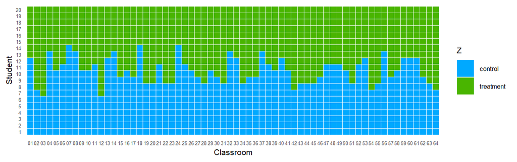

### 7.6.7 Block Random Assignment

- The treatment and control group will **in expectation** contain the same share of students in different classrooms.
- But as we saw this does necessarily hold in **realization**
- We make this more obvious by sorting the students by treatment status with schools

### 7.6.8 Blocked design

```r
assignment_blocked <-
  declare_assignment(Z = block_ra(blocks = classroom))

estimator_blocked <-
  declare_estimator(Y ~ Z, blocks = classroom,
                    .method = difference_in_means)

design_blocked <-
  design |>
  replace_step("assignment", assignment_blocked) |>
  replace_step("estimator", estimator_blocked)
```

### 7.6.9 Illustration of blocked assignment

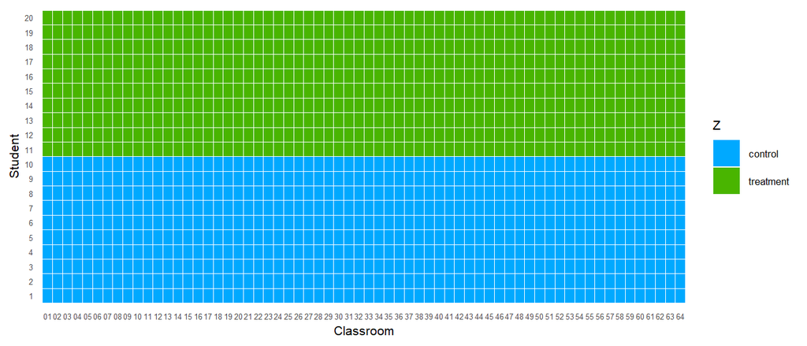

### 7.6.10 Clustering

But what if all students in a given class have to be assigned the same treatment?

```r
assignment_clustered <-
  declare_assignment(Z = cluster_ra(clusters = classroom))
estimator_clustered <-
  declare_estimator(Y ~ Z, clusters = classroom,
                    .method = difference_in_means)


design_clustered <-
  design |>
  replace_step("assignment", assignment_clustered) |>
  replace_step("estimator", estimator_clustered)
```

### 7.6.11 Illustration of clustered assignment

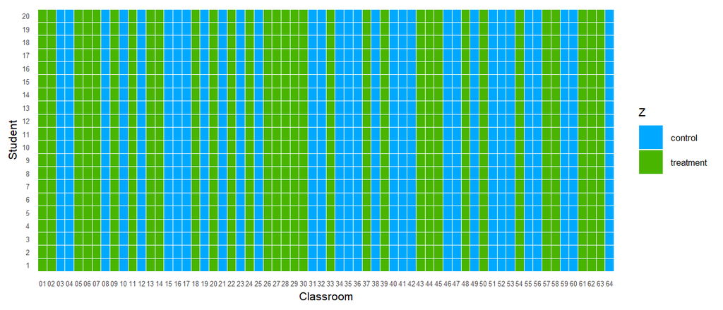

### 7.6.12 Clustered and Blocked

```r
assignment_clustered_blocked <-
  declare_assignment(Z = block_and_cluster_ra(blocks = school,
                                              clusters = classroom))
estimator_clustered_blocked <-
  declare_estimator(Y ~ Z, blocks = school, clusters = classroom,
                    .method = difference_in_means)


design_clustered_blocked <-
  design |>
  replace_step("assignment", assignment_clustered_blocked) |>
  replace_step("estimator", estimator_clustered_blocked)
```

### 7.6.13 Illustration of clustered and blocked assignment

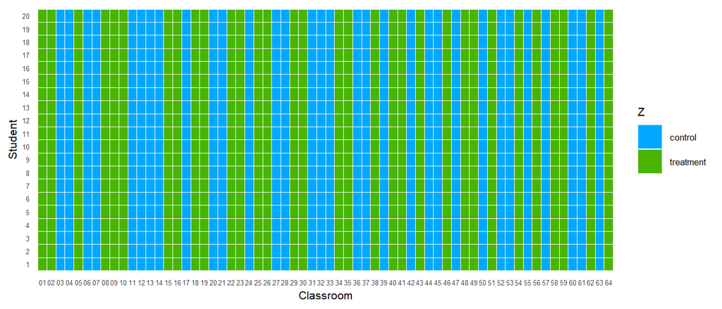

### 7.6.14 Illustration of efficiency gains from blocking

```r
designs <-
  list(
    simple = design,
    complete = design_complete,
    blocked = design_blocked,
    clustered = design_clustered,
    clustered_blocked = design_clustered_blocked)
```

```r
diagnoses <- diagnose_design(designs)
```

### 7.6.15 Illustration of efficiency gains from blocking

| Design | Power | Coverage |
| --- | --- | --- |
| simple | 0.16 | 0.95 |
|  | (0.01) | (0.01) |
| complete | 0.20 | 0.96 |
|  | (0.01) | (0.01) |
| blocked | 0.42 | 0.95 |
|  | (0.01) | (0.01) |
| clustered | 0.06 | 0.96 |
|  | (0.01) | (0.01) |
| clustered_blocked | 0.08 | 0.96 |
|  | (0.01) | (0.01) |

### 7.6.16 Sampling distributions

```r
diagnoses$simulations_df |>
  mutate(design = factor(design, c("blocked", "complete", "simple", "clustered_blocked", "clustered"))) |>
  ggplot(aes(estimate)) +
  geom_histogram() + facet_grid(~design)
```

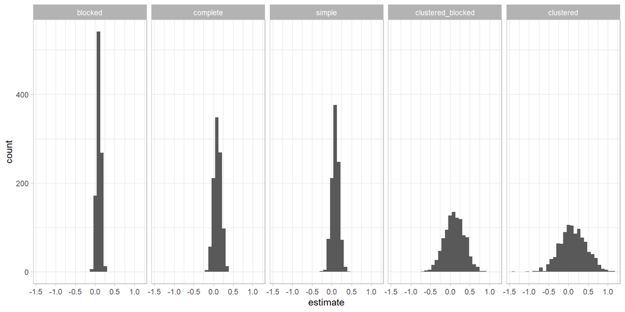

### 7.6.17 Nasty integer issues

- In many designs you seek to assign an integer number of subjects to treatment from some set.
- Sometimes however your assignment targets are not integers.

Example:

- I have 12 subjects in four blocks of 3 and I want to assign each subject to treatment with a 50% probability.

Two strategies:

1. I randomly set a target of either 1 or 2 for each block and then do complete assignment in each block. This can result in the numbers treated varying from 4 to 8
2. I randomly assign a target of 1 for two blocks and 2 for the other two blocks: **Intuition**–set a floor for the minimal target and then distribue the residual probability across blocks

### 7.6.18 Nasty integer issues

```r
# remotes::install_github("macartan/probra")
library(probra)
set.seed(1)

blocks <- rep(1:4, each = 3)

table(blocks, prob_ra(blocks = blocks))
```

```
blocks 0 1
     1 1 2
     2 1 2
     3 2 1
     4 2 1
```

```r
table(blocks, block_ra(blocks = blocks))
```

```
blocks 0 1
     1 1 2
     2 2 1
     3 1 2
     4 1 2
```

### 7.6.19 Nasty integer issues

Can also be used to set targets

```r
# remotes::install_github("macartan/probra")
library(probra)
set.seed(1)

fabricate(N = 4,  size = c(47, 53, 87, 25), n_treated = prob_ra(.5*size)) %>%
  janitor::adorn_totals("row") |>
  kable(caption = "Setting targets to get 50% targets with minimal variance")
```

Setting targets to get 50% targets with minimal variance

| ID | size | n_treated |
| --- | --- | --- |
| 1 | 47 | 23 |
| 2 | 53 | 27 |
| 3 | 87 | 43 |
| 4 | 25 | 13 |
| Total | 212 | 106 |

### 7.6.20 Nasty integer issues

Can also be used to set for complete assignment with heterogeneous propensities

```r
set.seed(1)

df <- fabricate(N = 100,  p = seq(.1, .9, length = 100), Z = prob_ra(p))

mean(df$Z)
```

```
[1] 0.5
```

```r
df |> ggplot(aes(p, Z)) + geom_point() + theme_bw()
```

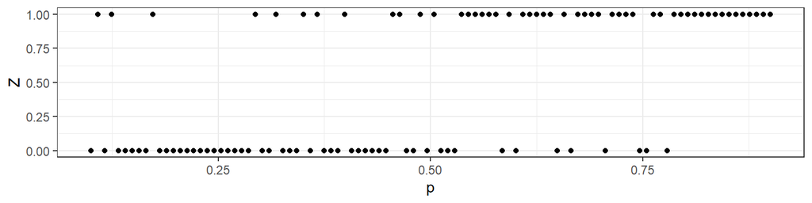

## 7.7 Indirect assignments

*Indirect control*

### 7.7.1 Indirect assignments

Indirect assignments are generally generated by applying a direct assignment and then figuring our an implied indirect assignment

```r
set.seed(1)

df <-
  fabricate(
    N = 100,
    latitude = runif(N),
    longitude = runif(N))

adjacency <-
  sapply(1:nrow(df), function(i)
    1*((df$latitude[i] - df$latitude)^2 + (df$longitude[i] - df$longitude)^2)^.5 < .1)

diag(adjacency) <- 0
```

### 7.7.2 Indirect assignments

```r
adjacency |>
  reshape2::melt(c("x", "y"), value.name = "z") |> mutate(z = factor(z)) |>
  ggplot(aes(x=x,y=y,fill=z))+
  geom_tile()
```

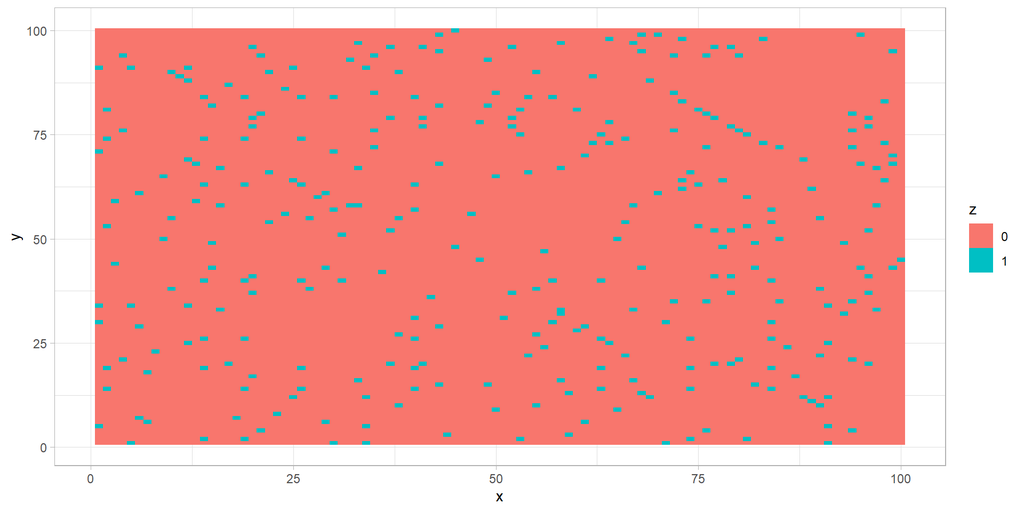

### 7.7.3 Indirect assignments

```r
n_assigned <- 50

design <-
  declare_model(data = df) +
  declare_assignment(
    direct = complete_ra(N, m = n_assigned),
    indirect = 1*(as.vector(as.vector(direct) %*% adjacency) >= 1))

draw_data(design) |> with(table(direct, indirect))
```

```
      indirect
direct  0  1
     0 13 37
     1 13 37
```

### 7.7.4 Indirect assignments: Properties

```r
indirect_propensities <- replicate(5000, draw_data(design)$indirect) |>
  apply(1, mean)
```

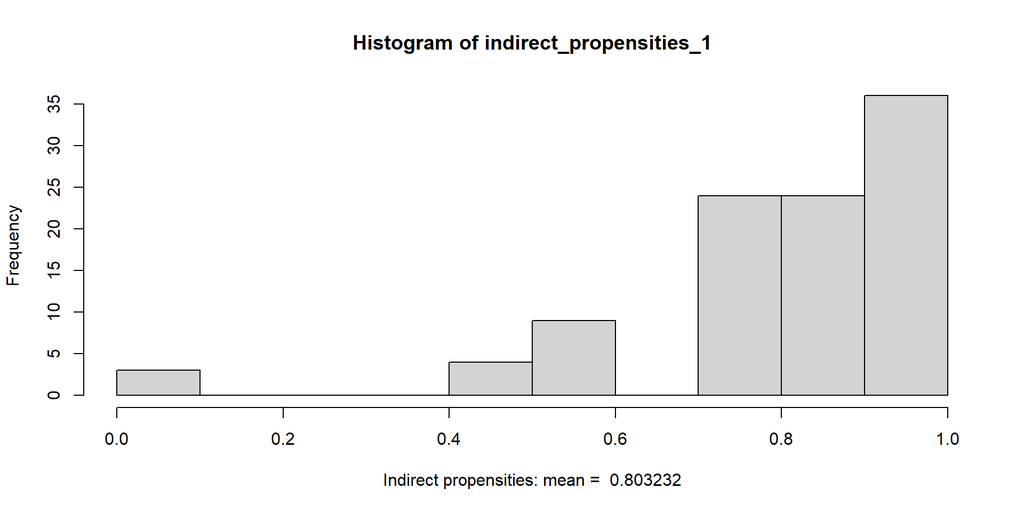

### 7.7.5 Indirect assignments: Properties

```r
df |> ggplot(aes(latitude, longitude, label = round(indirect_propensities_1, 2))) + geom_text()
```

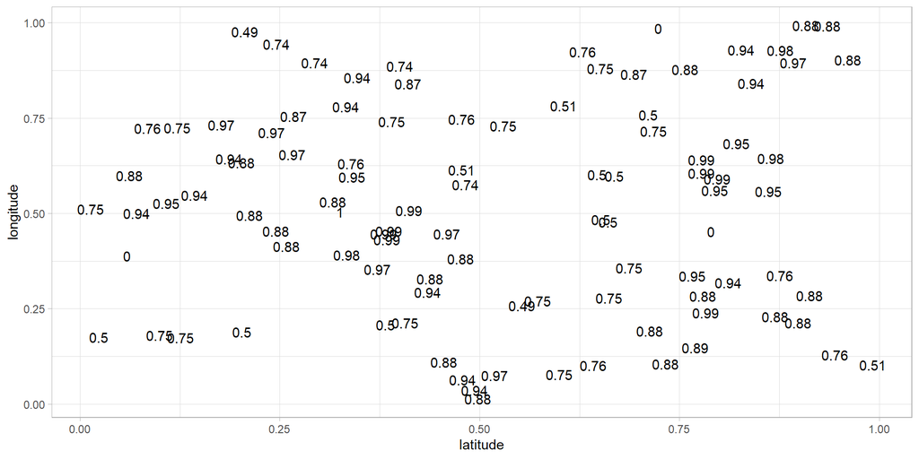

### 7.7.6 Indirect assignments: Redesign

```r
replicate(5000, draw_data(design |> redesign(n_assigned = 25))$indirect) |>
  apply(1, mean)
```

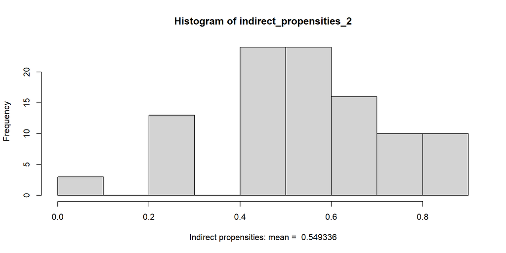

### 7.7.7 Indirect assignments: Redesign

```r
df |> ggplot(aes(latitude, longitude, label = round(indirect_propensities_2, 2))) +
  geom_text()
```

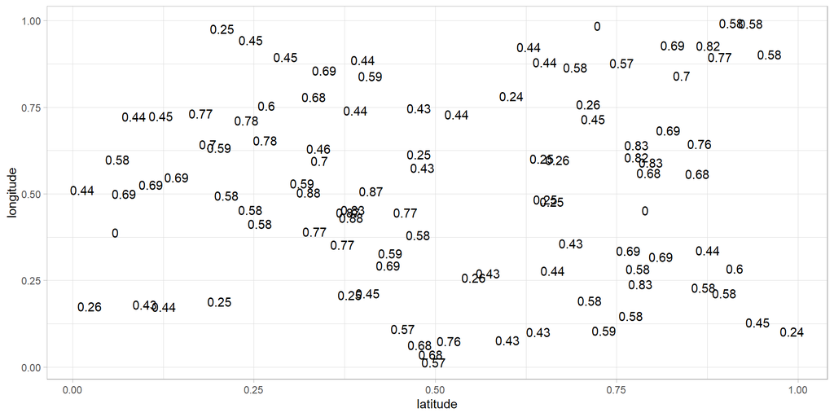

Looks better: *but there are trade offs between the direct and indirect distributions*

Figuring out the optimal procedure requires full diagnosis

# 8 Design diagnosis

*A focus on power*

## 8.1 Outline

1. Tests review
2. $p$ values and significance
3. Power
4. Sources of power
5. Advanced applications

## 8.2 Tests

### 8.2.1 Review

In the classical approach to testing a hypothesis we ask:

**How likely are we to see data like this if indeed the hypothesis is true?**

- If the answer is “not very likely” then we treat the hypothesis as suspect.
- If the answer is *not* “not very likely” then the hypothesis is maintained (some say “accepted” but this is tricky as you may want to “maintain” multiple incompatible hypotheses)

How unlikely is “not very likely”?

### 8.2.2 Weighing Evidence

When we test a hypothesis we decide first on what sort of evidence we need to see in order to decide that the hypothesis is not reliable.

- **Othello** has a hypothesis that Desdemona is innocent.
- **Iago** confronts him with evidence:
  - See how she looks at him: would she look a him like that if she were innocent?
  - … would she defend him like that if she were innocent?
  - … would he have her handkerchief if she were innocent?
  - Othello, the chances of all of these things arising if she were innocent is surely less than 5%

### 8.2.3 Hypotheses are often rejected, sometimes maintained, but rarely accepted

- Note that Othello is focused on the probability of the events if she were innocent but not the probability of the events if Iago were trying to trick him.
- He is not assessing his belief in whether she is faithful, but rather how likely the data would be if she were faithful.

So:

- He assesses: $\Pr(\text{Data} | \text{Hypothesis is TRUE})$
- While a Bayesian would assess: $\Pr(\text{Hypothesis is TRUE} | \text{Data})$

### 8.2.4 Recap: Calculate a $p$ value in your head

- Illustrating $p$ values via “randomization inference”
- Say you randomized assignment to treatment and your data looked like this.

| Unit | 1 | 2 | 3 | 4 | 5 | 6 | 7 | 8 | 9 | 10 |
| --- | --- | --- | --- | --- | --- | --- | --- | --- | --- | --- |
| Treatment | 0 | 0 | 0 | 0 | 0 | 0 | 0 | 1 | 0 | 0 |
| Health score | 4 | 2 | 3 | 1 | 2 | 3 | 4 | 8 | 7 | 6 |

Then:

- Does the treatment improve your health?
- What’s the $p$ value for the null that treatment had no effect on anybody?

## 8.3 Power

## 8.4 What power is

Power is just the probability of getting a significant result rejecting a hypothesis.

Simple enough but it presupposes:

- A well defined hypothesis
- An actual stipulation of the world under which you evaluate the probability
- A procedure for producing results and determining of they are significant / rejecting a hypothesis

### 8.4.1 By hand

I want to test the hypothesis that a six never comes up on this dice.

Here’s my **test**:

- I will roll the dice **once**.
- If a six comes up I will reject the hypothesis.

What is the power of this test?

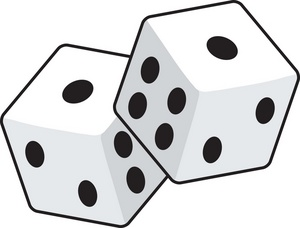

### 8.4.2 By hand

I want to test the hypothesis that a six never comes up on this dice.

Here’s my **test**:

- I will roll the dice **twice**.
- If a six comes up **either time** I will reject the hypothesis.

What is the power of *this* test?

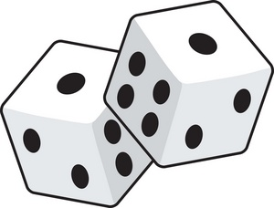

### 8.4.3 Two probabilities

Power sometimes seems more complicated because hypothesis rejection involves a calculated probability and so you need the probability of a probability.

I want to test the hypothesis that this dice is *fair*.

Here’s my **test**:

- I will roll the dice **1000** times and if I see fewer than *x* 6s or more than *y* 6s I will reject the hypothesis.

Now:

- What should *x* and *y* be?
- What is the power of this test?

### 8.4.4 Step 1: When do you reject?

For this we need to figure a rule for rejection. This is based on identifying events that should be unlikely under the hypothesis.

Here is how many 6’s I would expect if the dice is fair:

```r
fabricate(N = 1001, sixes = 0:1000, p = dbinom(sixes, 1000, 1/6)) |>
  ggplot(aes(sixes, p)) + geom_line()
```

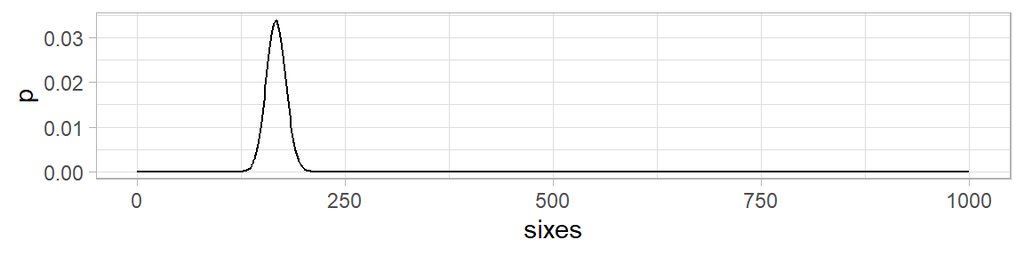

### 8.4.5 Step 1: When do you reject?

I can figure out from this that 143 or fewer is really very few and 190 or more is really very many:

```r
c(lower = pbinom(143, 1000, 1/6), upper = 1 - pbinom(189, 1000, 1/6))
```

```
     lower      upper
0.02302647 0.02785689
```

### 8.4.6 Step 2: What is the power?

- Now we need to stipulate some belief about how the world really works—this is not the null hypothesis that we plan to reject, but something that we actually take to be true.
- For instance: we think that *in fact* sixes appear 20% of the time.

Now what’s the probability of seeing at least 190 sixes?

```r
1 - pbinom(189, 1000, .2)
```

```
[1] 0.796066
```

So given I think 6s appear 20% of the time, I think it likely I’ll see at least 190 sixes and reject the hypothesis of a fair dice.

### 8.4.7 Rule of thumb

- 80% or 90% is a common rule of thumb for “sufficient” power
- but really, how much power you need depends on the purpose

### 8.4.8 Think about

- Are there other tests I could have implemented?
- Are there other ways to improve this test?

### 8.4.9 Subtleties

- Is a significant result from an underpowered study less credible? (only if there is a significance filter)
- What significance level should you choose for power? (Obviously the stricter the level the lower the power, so use what you will use when you actually implement tests)
- Do you really have to know the effect size to do power analysis? (No, but you should know at least what effects sizes you would want to be sure about picking up if they were present)
- Power is just one of many possible diagnosands
- What’s power for Bayesians?

### 8.4.10 Power analytics

Simplest intuition on power:

What is the probability of getting a significant estimate given the sampling distribution is centered on $b$ and the *standard error* is 1?

- Probability below -1.96: $F(-1.96 | \tau))$
- Probability above -1.96: $1-F(1.96 | \tau)$

Add these together: probability of getting an estimate above 1.96 or below -1.96.

```r
power <- function(b, alpha = 0.05, critical = qnorm(1-alpha/2))

  1 - pnorm(critical, mean = abs(b)) + pnorm(-critical, mean = abs(b))
```

```r
power(0)
```

```
[1] 0.05
```

```r
power(1.96)
```

```
[1] 0.5000586
```

```r
power(-1.96)
```

```
[1] 0.5000586
```

```r
power(3)
```

```
[1] 0.8508388
```

### 8.4.11 Power analytics: graphed

This is essentially what is done by `pwrss::power.z.test` – and it produces nice graphs!

See:

```r
pwrss::power.z.test(ncp = 1.96, alpha = 0.05, alternative = "not equal", plot = TRUE)
```

```
     power ncp.alt ncp.null alpha  z.crit.1 z.crit.2
 0.5000586    1.96        0  0.05 -1.959964 1.959964
```

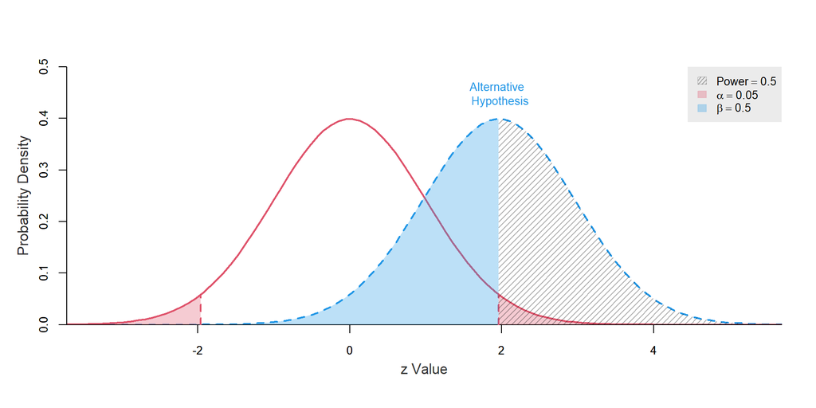

### 8.4.12 Power analytics: graphed

Substantively: if in expectation an estimate will be *just* significant, then your power is 50%

### 8.4.13 Equivalent

```r
power <- function(b, alpha = 0.05, critical = qnorm(1-alpha/2))

  1 - pnorm(critical - b) + pnorm(-critical - b)

power(1.96)
```

```
[1] 0.5000586
```

Intuition:

```r
x <- seq(-3, 3, .01)
plot(x, dnorm(x), main = "power associated with effect of 1 se")
abline(v = 1.96 - 1)
abline(v = -1.96 - 1)
```

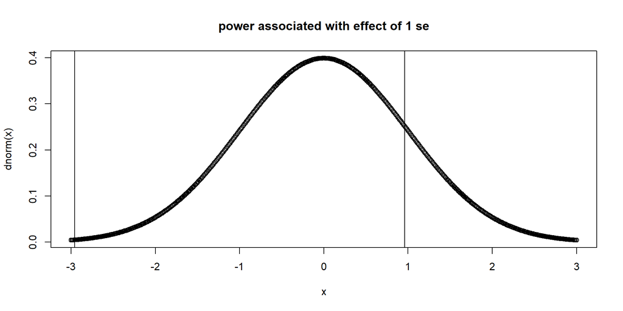

### 8.4.14 Power analytics for a trial: by hand

- Of course the standard error will depend on the number of units and the variance of outcomes in treatment and control.
- Say $N$ subject are divided into two groups and potential outcomes have standard deviation $\sigma$ in treatment and control. Then the conservative variance of the treatment effect is (approx / conservatively):

$$Var(\tau)=\frac{\sigma^2}{N/2} + \frac{\sigma^2}{N/2} = 4\frac{\sigma^2}{N}$$

and so the (conservative / approx) standard error is:

$$\sigma_\tau=\frac{2\sigma}{\sqrt{N}}$$

Note here we seem to be using the actual standard error but of course the tests we actually run will use an *estimate* of the standard error…

### 8.4.15 Power analytics for a trial: by hand

```r
se <- function(sd, N) (N/(N-1))^.5*2*sd/(N^.5)


power_2 <- function(b, alpha = .05, sd = 1, N = 100, critical = qnorm(1-alpha/2), se = 2*sd/N^.5)

  1 - pnorm(critical, mean = abs(b)/se(sd, N)) + pnorm(-critical, mean = abs(b)/se(sd, N))

power_2(0)
```

```
[1] 0.05
```

```r
power_2(.5)
```

```
[1] 0.7010827
```

### 8.4.16 Power analytics for a trial: flexible

This can be done e.g. with `pwrss` like this:

```r
pwrss::pwrss.t.2means(mu1 = .2, mu2 = .1, sd1 = 1, sd2 = 1,
               n2 = 50, alpha = 0.05,
               alternative = "not equal")
```

```
 Difference between Two means
 (Independent Samples t Test)
 H0: mu1 = mu2
 HA: mu1 != mu2
 ------------------------------
  Statistical power = 0.079
  n1 = 50
  n2 = 50
 ------------------------------
 Alternative = "not equal"
 Degrees of freedom = 98
 Non-centrality parameter = 0.5
 Type I error rate = 0.05
 Type II error rate = 0.921
```

```r
power_2(.50, N = 100)
```

```
[1] 0.7010827
```

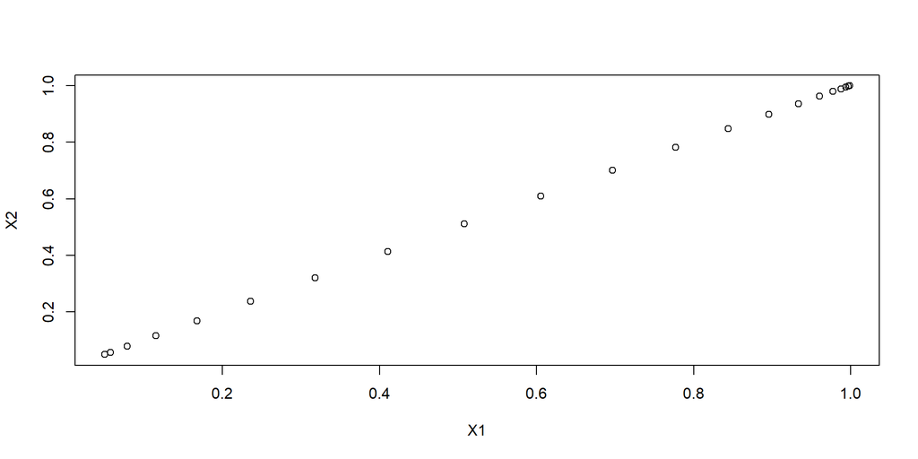

### 8.4.17 Power for more complex trials: Analytics

Mostly involve figuring out the standard error.

Consider a cluster randomized trial, with each unit having a cluster level shock $\epsilon_k$ and an individual shock $\nu_i$. Say these have variances $\sigma^2_k$, $\sigma^2_i$.

The standard error is:

$$\sqrt{\frac{4\sigma^2_k}{K} + \frac{4\sigma^2_i}{nK}}$$

Define $\rho = \frac{\sigma^2_k}{\sigma^2_k + \sigma^2_i}$

$$\sqrt{\rho \frac{4\sigma^2}{K} + (1- \rho)\frac{4\sigma^2}{nK}}$$

$$\sqrt{((n - 1)\rho + 1)\frac{4\sigma^2}{nK}}$$

where

- $((n - 1)\rho + 1)$ is the “design effect”
- $\frac{nK}{((n - 1)\rho + 1)}$ is the “effective sample size”

Plug in these standard errors and proceed as before

### 8.4.18 Power via design diagnosis

*Is arbitrarily flexible*

```r
N <- 100
b <- .5

design <-
  declare_model(N = N,
    U = rnorm(N),
    potential_outcomes(Y ~ b * Z + U)) +
  declare_assignment(Z = simple_ra(N),
                     Y = reveal_outcomes(Y ~ Z)) +
  declare_inquiry(ate = mean(Y_Z_1 - Y_Z_0)) +
  declare_estimator(Y ~ Z, inquiry = "ate", .method = lm_robust)
```

### 8.4.19 Run it many times

```r
sims_1 <- simulate_design(design)

sims_1 |> select(sim_ID, estimate, p.value)
```

| sim_ID | estimate | p.value |
| --- | --- | --- |
| 1 | 0.81 | 0.00 |
| 2 | 0.40 | 0.04 |
| 3 | 0.88 | 0.00 |
| 4 | 0.72 | 0.00 |
| 5 | 0.38 | 0.05 |
| 6 | 0.44 | 0.02 |

### 8.4.20 Power is mass of the sampling distribution of decisions under the model

```r
sims_1 |>
  ggplot(aes(p.value)) +
  geom_histogram() +
  geom_vline(xintercept = .05, color = "red")
```

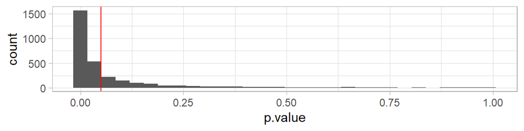

### 8.4.21 Power is mass of the sampling distribution of decisions under the model

Obviously related to the estimates you might get

```r
sims_1 |>
  mutate(significant = p.value <= .05) |>
  ggplot(aes(estimate, p.value, color = significant)) +
  geom_point()
```

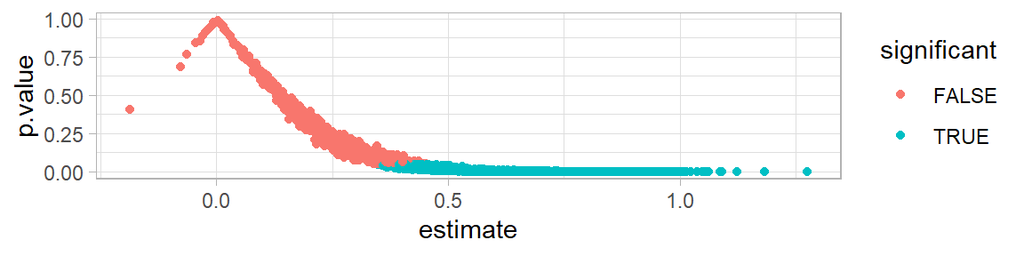

### 8.4.22 Check coverage is correct

```r
sims_1 |>
  mutate(within = (b > sims_1$conf.low) & (b < sims_1$conf.high)) |>
  pull(within) |> mean()
```

```
[1] 0.9573333
```

### 8.4.23 Check validity of $p$ value

A valid $p$-value satisfies $\Pr(p≤x)≤x$ for every $x \in[0,1]$ (under the null)

```r
sims_2 <-

  redesign(design, b = 0) |>

  simulate_design()
```

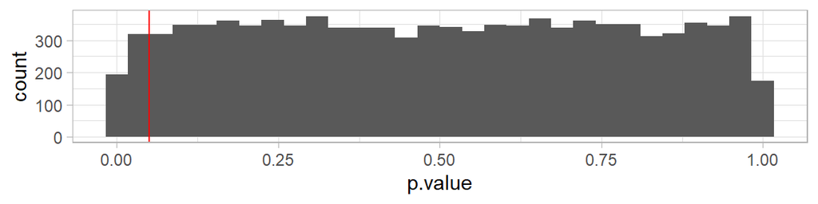

### 8.4.24 Design diagnosis does it all (over multiple designs)

```r
  diagnose_design(design)
```

| Mean Estimate | Bias | SD Estimate | RMSE | Power | Coverage |
| --- | --- | --- | --- | --- | --- |
| 0.50 | 0.00 | 0.20 | 0.20 | 0.70 | 0.95 |
| (0.00) | (0.00) | (0.00) | (0.00) | (0.00) | (0.00) |

### 8.4.25 Design diagnosis does it all

```r
design |>
  redesign(b = c(0, 0.25, 0.5, 1)) |>
  diagnose_design()
```

| b | Mean Estimate | Bias | SD Estimate | RMSE | Power | Coverage |
| --- | --- | --- | --- | --- | --- | --- |
| 0 | -0.00 | -0.00 | 0.20 | 0.20 | 0.05 | 0.95 |
|  | (0.00) | (0.00) | (0.00) | (0.00) | (0.00) | (0.00) |
| 0.25 | 0.25 | -0.00 | 0.20 | 0.20 | 0.23 | 0.95 |
|  | (0.00) | (0.00) | (0.00) | (0.00) | (0.00) | (0.00) |
| 0.5 | 0.50 | 0.00 | 0.20 | 0.20 | 0.70 | 0.95 |
|  | (0.00) | (0.00) | (0.00) | (0.00) | (0.00) | (0.00) |
| 1 | 1.00 | 0.00 | 0.20 | 0.20 | 1.00 | 0.95 |
|  | (0.00) | (0.00) | (0.00) | (0.00) | (0.00) | (0.00) |

### 8.4.26 Diagnose over multiple moving parts (and ggplot)

```r
design |>
  ## Redesign
  redesign(b = c(0.1, 0.3, 0.5), N = 100, 200, 300) |>
  ## Diagnosis
  diagnose_design() |>
  ## Prep
  tidy() |>
  filter(diagnosand == "power") |>
  ## Plot
  ggplot(aes(N, estimate, color = factor(b))) +
  geom_line()
```

### 8.4.27 Diagnose over multiple moving parts (and ggplot)

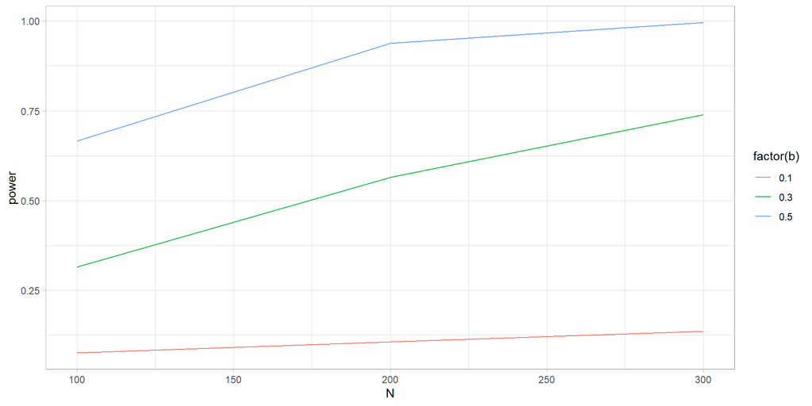

### 8.4.28 Diagnose over multiple moving parts and multiple diagnosands (and ggplot)

```r
design |>

  ## Redesign
  redesign(b = c(0.1, 0.3, 0.5), N = 100, 200, 300) |>

  ## Diagnosis
  diagnose_design() |>

  ## Prep
  tidy() |>

  ## Plot
  ggplot(aes(N, estimate, color = factor(b))) +
  geom_line()+
  facet_wrap(~diagnosand)
```

### 8.4.29 Diagnose over multiple moving parts and multiple diagnosands (and ggplot)

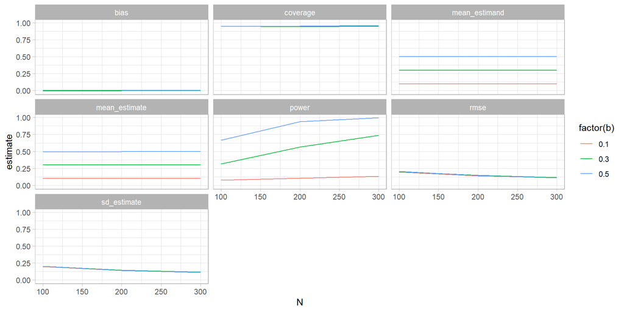

## 8.5 Beyond basics

### 8.5.1 Power tips

coming up:

- power everywhere
- power with bias
- power with the wrong standard errors
- power with uncertainty over effect sizes
- power and multiple comparisons

### 8.5.2 Power depends on all parts of MIDA

We often focus on sample sizes

**But**

Power also depends on

- the model – obviously signal to noise
- the assignments and specifics of sampling strategies
- estimation procedures

### 8.5.3 Power from a lag?

Say we have access to a “pre” measure of outcome `Y_now`; call it `Y_base`. `Y_base` is informative about potential outcomes. We are considering using `Y_now - Y_base` as the outcome instead of `Y_now`.

```r
N <- 100
rho <- .5

design <-
  declare_model(N,
                 Y_base = rnorm(N),
                 Y_Z_0 = 1 + correlate(rnorm, given = Y_base, rho = rho),
                 Y_Z_1 = correlate(rnorm, given = Y_base, rho = rho),
                 Z = complete_ra(N),
                 Y_now = Z*Y_Z_1 + (1-Z)*Y_Z_0,
                 Y_change = Y_now - Y_base) +
  declare_inquiry(ATE = mean(Y_Z_1 - Y_Z_0)) +
  declare_estimator(Y_now ~ Z, label = "level") +
  declare_estimator(Y_change ~ Z, label = "change")+
  declare_estimator(Y_now ~ Z + Y_base, label = "RHS")
```

### 8.5.4 Power from a lag?

```r
design |> redesign(N = c(10, 100, 1000, 10000), rho = c(.1, .5, .9)) |>
  diagnose_design()
```

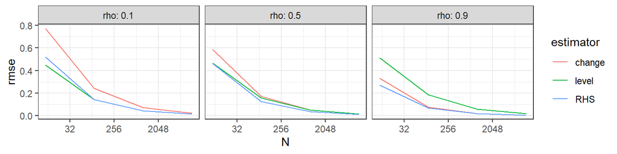

### 8.5.5 Power from a lag?

Punchline:

- if you difference: *the lag has to be sufficiently information to pay its way* (the $\rho = .5$ equivalent between level and change follows from Gerber and Green (2012) equation 4.6)
- The right hand side is your friend, at least for experiments ([Ding and Li (2019)](https://arxiv.org/abs/1903.06286))
- As $N$ grows the stakes fall

### 8.5.6 Power when estimates are biased

```r
bad_design <-

  declare_model(N = 100,
    U = rnorm(N),
    potential_outcomes(Y ~ 0 * X + U, conditions = list(X = 0:1)),
    X = ifelse(U > 0, 1, 0)) +

  declare_measurement(Y = reveal_outcomes(Y ~ X)) +

  declare_inquiry(ate = mean(Y_X_1 - Y_X_0)) +

  declare_estimator(Y ~ X, inquiry = "ate", .method = lm_robust)
```

### 8.5.7 Power when estimates are biased

You can see from the null design that power is great but bias is terrible and coverage is way off.

```r
diagnose_design(bad_design)
```

| Mean Estimate | Bias | SD Estimate | RMSE | Power | Coverage |
| --- | --- | --- | --- | --- | --- |
| 1.59 | 1.59 | 0.12 | 1.60 | 1.00 | 0.00 |
| (0.01) | (0.01) | (0.00) | (0.01) | (0.00) | (0.00) |

Power without unbiasedness corrupts, absolutely

### 8.5.8 Power with a more subtly biased experimental design

```r
another_bad_design <-

  declare_model(
    N = 100,
    female = rep(0:1, N/2),
    U = rnorm(N),
    potential_outcomes(Y ~ female * Z + U)) +

  declare_assignment(
    Z = block_ra(blocks = female, block_prob = c(.1, .5)),
    Y = reveal_outcomes(Y ~ Z)) +

  declare_inquiry(ate = mean(Y_Z_1 - Y_Z_0)) +

  declare_estimator(Y ~ Z + female, inquiry = "ate",
                    .method = lm_robust)
```

```r
  diagnose_design(another_bad_design)
```

### 8.5.9 Power with a more subtly biased experimental design

You can see from the null design that power is great but bias is terrible and coverage is way off.

| Mean Estimate | Bias | SD Estimate | RMSE | Power | Coverage |
| --- | --- | --- | --- | --- | --- |
| 0.76 | 0.26 | 0.24 | 0.35 | 0.84 | 0.85 |
| (0.01) | (0.01) | (0.01) | (0.01) | (0.01) | (0.02) |

### 8.5.10 Power with the wrong standard errors

```r
clustered_design <-
  declare_model(
    cluster = add_level(N = 10, cluster_shock = rnorm(N)),
    individual = add_level(
        N = 100,
        Y_Z_0 = rnorm(N) + cluster_shock,
        Y_Z_1 = rnorm(N) + cluster_shock)) +
  declare_inquiry(ATE = mean(Y_Z_1 - Y_Z_0)) +
  declare_assignment(Z = cluster_ra(clusters = cluster)) +
  declare_measurement(Y = reveal_outcomes(Y ~ Z)) +
  declare_estimator(Y ~ Z, inquiry = "ATE")
```

| Mean Estimate | Bias | SD Estimate | RMSE | Power | Coverage |
| --- | --- | --- | --- | --- | --- |
| -0.00 | -0.00 | 0.64 | 0.64 | 0.79 | 0.20 |
| (0.01) | (0.01) | (0.01) | (0.01) | (0.01) | (0.01) |

What alerts you to a problem?

### 8.5.11 Let’s fix that one

```r
clustered_design_2  <-
  clustered_design |> replace_step(5,
  declare_estimator(Y ~ Z, clusters = cluster))
```

| Mean Estimate | Bias | SD Estimate | RMSE | Power | Coverage |
| --- | --- | --- | --- | --- | --- |
| 0.00 | -0.00 | 0.66 | 0.65 | 0.06 | 0.94 |
| (0.02) | (0.02) | (0.01) | (0.01) | (0.01) | (0.01) |

### 8.5.12 Power when you are not sure about effect sizes (always!)

- you can do power analysis for multiple stipulations
- or you can design with a distribution of effect sizes

```r
design_uncertain <-
  declare_model(N = 1000, b = 1+rnorm(1), Y_Z_1 = rnorm(N), Y_Z_2 = rnorm(N) + b, Y_Z_3 = rnorm(N) + b) +
  declare_assignment(Z = complete_ra(N = N, num_arms = 3, conditions = 1:3)) +
  declare_measurement(Y = reveal_outcomes(Y ~ Z)) +
  declare_inquiry(ate = mean(b)) +
  declare_estimator(Y ~ factor(Z), term = TRUE)

draw_estimands(design_uncertain)
```

```
  inquiry   estimand
1     ate -0.3967765
```

```r
draw_estimands(design_uncertain)
```

```
  inquiry  estimand
1     ate 0.7887188
```

### 8.5.13 Multiple comparisons correction (complex code)

Say I run two tests and want to correct for multiple comparisons.

Two approaches. First, by hand:

```r
b = .2

design_mc <-
  declare_model(N = 1000, Y_Z_1 = rnorm(N), Y_Z_2 = rnorm(N) + b, Y_Z_3 = rnorm(N) + b) +
  declare_assignment(Z = complete_ra(N = N, num_arms = 3, conditions = 1:3)) +
  declare_measurement(Y = reveal_outcomes(Y ~ Z)) +
  declare_inquiry(ate = b) +
  declare_estimator(Y ~ factor(Z), term = TRUE)
```

### 8.5.14 Multiple comparisons correction (complex code)

```r
design_mc |>
  simulate_designs(sims = 1000) |>
  filter(term != "(Intercept)") |>
  group_by(sim_ID) |>
  mutate(p_bonferroni = p.adjust(p = p.value, method = "bonferroni"),
         p_holm = p.adjust(p = p.value, method = "holm"),
         p_fdr = p.adjust(p = p.value, method = "fdr")) |>
  ungroup() |>
  summarize(
    "Power using naive p-values" = mean(p.value <= 0.05),
    "Power using Bonferroni correction" = mean(p_bonferroni <= 0.05),
    "Power using Holm correction" = mean(p_holm <= 0.05),
    "Power using FDR correction" = mean(p_fdr <= 0.05)
    )
```

| Power using naive p-values | Power using Bonferroni correction | Power using Holm correction | Power using FDR correction |
| --- | --- | --- | --- |
| 0.7374 | 0.6318 | 0.6886 | 0.7032 |

### 8.5.15 Multiple comparisons correction (approach 2)

The alternative approach (generally better!) is to design with a custom estimator that includes your corrections.

```r
my_estimator <- function(data)
  lm_robust(Y ~ factor(Z), data = data) |>
  tidy() |>
  filter(term != "(Intercept)") |>
  mutate(p.naive = p.value,
         p.value = p.adjust(p = p.naive, method = "bonferroni"))


design_mc_2 <- design_mc |>
  replace_step(5, declare_estimator(handler = label_estimator(my_estimator)))

run_design(design_mc_2) |>
  select(term, estimate, p.value, p.naive) |> kable()
```

| term | estimate | p.value | p.naive |
| --- | --- | --- | --- |
| factor(Z)2 | 0.1182516 | 0.2502156 | 0.1251078 |
| factor(Z)3 | 0.1057031 | 0.3337476 | 0.1668738 |

### 8.5.16 Multiple comparisons correction (Null model case)

Lets try same thing for a null model (using `redesign(design_mc_2, b = 0)`)

```r
design_mc_3 <-
  design_mc_2 |>
  redesign(b = 0)

run_design(design_mc_3) |> select(estimate, p.value, p.naive) |> kable(digits = 3)
```

| estimate | p.value | p.naive |
| --- | --- | --- |
| 0.068 | 0.799 | 0.399 |
| 0.144 | 0.151 | 0.076 |

### 8.5.17 Multiple comparisons correction (Null model case)

…and power:

| Mean Estimate | Bias | SD Estimate | RMSE | Power | Coverage |
| --- | --- | --- | --- | --- | --- |
| 0.00 | 0.00 | 0.08 | 0.08 | 0.02 | 0.95 |
| (0.00) | (0.00) | (0.00) | (0.00) | (0.00) | (0.01) |
| -0.00 | -0.00 | 0.08 | 0.08 | 0.02 | 0.96 |
| (0.00) | (0.00) | (0.00) | (0.00) | (0.00) | (0.01) |

bothered?

### 8.5.18 You might try

- Power for an interaction (in a factorial design)
- Power for a binary variable (versus a continuous variable?)
- Power gains from blocked randomization
- Power losses from clustering at different levels
- Controlling the ICC directly? (see book cluster designs section)

### 8.5.19 Big takeaways

- Power is affected not just by sample size, variability and effect size but also by you data and analysis strategies.
- Try to estimate power under multiple scenarios
- Try to use the same code for calculating power as you will use in your ultimate analysis
- Basically the same procedure can be used for any design. If you can declare a design and have a test, you can calculate power
- Your power might be right but misleading. For confidence:
  - Don’t just check power, check bias and coverage also
  - Check power especially *under the null*
- Don’t let a focus on power distract you from more *substantive* diagnosands

# 9 Topics

*Introduction to observational strategies and more advanced topics*

## 9.1 Outline

- LATE
- Diff in Diff
- RDD
- Spillovers
- Mediation
- Survey experiments

## 9.2 Noncompliance and the LATE estimand

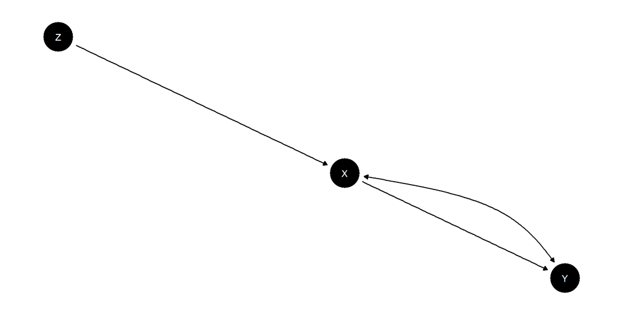

### 9.2.1 Local Average Treatment Effects

Sometimes you give a medicine but only a nonrandom sample of people actually try to use it. Can you still estimate the medicine’s effect?

|  | X=0 | X=1 |
| --- | --- | --- |
| Z=0 | $\overline{y}_{00}$ ($n_{00}$) | $\overline{y}_{01}$ ($n_{01}$) |
| Z=1 | $\overline{y}_{10}$ ($n_{10}$) | $\overline{y}_{11}$ ($n_{11}$) |

Say that people are one of 3 types:

1. $n_a$ “always takers” have $X=1$ no matter what and have average outcome $\overline{y}_a$
2. $n_n$ “never takers” have $X=0$ no matter what with outcome $\overline{y}_n$
3. $n_c$ “compliers have” $X=Z$ and average outcomes $\overline{y}^1_c$ if treated and $\overline{y}^0_c$ if not.

### 9.2.2 Local Average Treatment Effects

Sometimes you give a medicine but only a non random sample of people actually try to use it. Can you still estimate the medicine’s effect?

|  | X=0 | X=1 |
| --- | --- | --- |
| Z=0 | $\overline{y}_{00}$ ($n_{00}$) | $\overline{y}_{01}$ ($n_{01}$) |
| Z=1 | $\overline{y}_{10}$ ($n_{10}$) | $\overline{y}_{11}$ ($n_{11}$) |

We can figure something about types:

|  | $X=0$ | $X=1$ |
| --- | --- | --- |
| $Z=0$ | $\frac{\frac{1}{2}n_c}{\frac{1}{2}n_c + \frac{1}{2}n_n} \overline{y}^0_{c}+\frac{\frac{1}{2}n_n}{\frac{1}{2}n_c + \frac{1}{2}n_n} \overline{y}_{n}$ | $\overline{y}_{a}$ |
| $Z=1$ | $\overline{y}_{n}$ | $\frac{\frac{1}{2}n_c}{\frac{1}{2}n_c + \frac{1}{2}n_a} \overline{y}^1_{c}+\frac{\frac{1}{2}n_a}{\frac{1}{2}n_c + \frac{1}{2}n_a} \overline{y}_{a}$ |

### 9.2.3 Local Average Treatment Effects

You give a medicine to 50% but only a non random sample of people actually try to use it. Can you still estimate the medicine’s effect?

|  | $X=0$ | $X=1$ |
| --- | --- | --- |
| $Z=0$ | $\frac{n_c}{n_c + n_n} \overline{y}^0_{c}+\frac{n_n}{n_c + n_n} \overline{y}_n$ | $\overline{y}_{a}$ |
| (n) | ($\frac{1}{2}(n_c + n_n)$) | ($\frac{1}{2}n_a$) |
| $Z=1$ | $\overline{y}_{n}$ | $\frac{n_c}{n_c + n_a} \overline{y}^1_{c}+\frac{n_a}{n_c + n_a} \overline{y}_{a}$ |
| (n) | ($\frac{1}{2}n_n$) | ($\frac{1}{2}(n_a+n_c)$) |

Key insight: the contributions of the $a$s and $n$s are the *same* in the $Z=0$ and $Z=1$ groups so if you difference you are left with the *changes* in the contributions of the $c$s.

### 9.2.4 Local Average Treatment Effects

Average in $Z=0$ group: $\frac{{n_c} \overline{y}^0_{c}+ \left(n_{n}\overline{y}_{n} +{n_a} \overline{y}_a\right)}{n_a+n_c+n_n}$

Average in $Z=1$ group: $\frac{{n_c} \overline{y}^1_{c} + \left(n_{n}\overline{y}_{n} +{n_a} \overline{y}_a \right)}{n_a+n_c+n_n}$

So, the *difference* is the ITT: $({\overline{y}^1_c-\overline{y}^0_c})\frac{n_c}{n}$

Last step:

$$ITT = ({\overline{y}^1_c-\overline{y}^0_c})\frac{n_c}{n}$$

$$\leftrightarrow$$

$$LATE = \frac{ITT}{\frac{n_c}{n}}= \frac{\text{Intent to treat effect}}{\text{First stage effect}}$$

### 9.2.5 The good and the bad of LATE

- You get a well-defined estimate even when there is non-random take-up
- May sometimes be used to assess mediation or knock-on effects
- But:
  - You need assumptions (monotonicity and the exclusion restriction – *where were these used above*?)
  - Your estimate is only for a subpopulation
  - The subpopulation is not chosen by you and is unknown
  - Different encouragements may yield different estimates since they may encourage different subgroups

### 9.2.6 Pearl and Chickering again

With and without an imposition of monotonicity

```r
data("lipids_data")

models <-
  list(unrestricted =  make_model("Z -> X -> Y; X <-> Y"),
       restricted =  make_model("Z -> X -> Y; X <-> Y") |>
         set_restrictions("X[Z=1] < X[Z=0]")) |>
  lapply(update_model,  data = lipids_data, refresh = 0)

models |>
  query_model(query = list(CATE = "Y[X=1] - Y[X=0]",
                           Nonmonotonic = "X[Z=1] < X[Z=0]"),
              given = list("X[Z=1] > X[Z=0]", TRUE),
              using = "posteriors")
```

### 9.2.7 Pearl and Chickering again

With and without an imposition of monotonicity:

| model | query | mean | sd |
| --- | --- | --- | --- |
| unrestricted | CATE | 0.70 | 0.05 |
| restricted | CATE | 0.71 | 0.05 |
| unrestricted | Nonmonotonic | 0.01 | 0.01 |
| restricted | Nonmonotonic | 0.00 | 0.00 |

In one case we *assume* monotonicity, in the other we **update** on it (easy in this case because of the empirically verifiable nature of one sided non compliance)

## 9.3 Diff in diff

Key idea: the evolution of units in the control group allow you to impute what the evolution of units in the treatment group *would have been* had they not been treated

### 9.3.1 Logic

We have group $A$ that enters treatment at some point and group $B$ that never does

The estimate:

$$\hat\tau = (\mathbb{E}[Y^A | post] - \mathbb{E}[Y^A | pre]) -(\mathbb{E}[Y^B | post] - \mathbb{E}[Y^B | pre])$$
(how different is the change in $A$ compared to the change in $B$?)

can be written:

$$\hat\tau = (\mathbb{E}[Y_1^A | post] - \mathbb{E}[Y_0^A | pre]) -(\mathbb{E}[Y_0^B | post] - \mathbb{E}[Y_0^B | pre])$$

### 9.3.2 Logic

Cleaning up

$$\hat\tau = (\mathbb{E}[Y_1^A | post] - \mathbb{E}[Y_0^A | pre]) -(\mathbb{E}[Y_0^B | post] - \mathbb{E}[Y_0^B | pre])$$

$$\hat\tau = (\mathbb{E}[Y_1^A | post] - \mathbb{E}[Y_0^A | post]) + ((\mathbb{E}[Y_0^A | post] - \mathbb{E}[Y_0^A | pre]) -(\mathbb{E}[Y_0^B | post] - \mathbb{E}[Y_0^B | pre]))$$

$$\hat\tau_{ATT} = \tau_{ATT} + \text{Difference in trends}$$

### 9.3.3 Simplest case

```r
n_units <- 2
design <-
  declare_model(
    unit = add_level(N = n_units, I = 1:N),
    time = add_level(N = 6, T = 1:N, nest = FALSE),
    obs = cross_levels(by = join_using(unit, time))) +
  declare_model(potential_outcomes(Y ~ I + T^.5 + Z*T)) +
  declare_assignment(Z = 1*(I>(n_units/2))*(T>3)) +
  declare_measurement(Y = reveal_outcomes(Y~Z)) +
  declare_inquiry(ATE = mean(Y_Z_1 - Y_Z_0),
                  ATT = mean(Y_Z_1[Z==1] - Y_Z_0[Z==1])) +
  declare_estimator(Y ~ Z, label = "naive") +
  declare_estimator(Y ~ Z + I, label = "FE1") +
  declare_estimator(Y ~ Z + as.factor(T), label = "FE2") +
  declare_estimator(Y ~ Z + I + as.factor(T), label = "FE3")
```

### 9.3.4 Diagnosis

Here only the two way fixed effects is unbiased and only for the ATT.

The ATT here is averaging over effects for treated units (later periods only). We *know nothing* about the size of effects in earlier periods when all units are in control!

```r
design |> diagnose_design()
```

| Inquiry | Estimator | Bias |
| --- | --- | --- |
| ATE | FE1 | 2.25 |
| ATE | FE2 | 6.50 |
| ATE | FE3 | 1.50 |
| ATE | naive | 5.40 |
| ATT | FE1 | 0.75 |
| ATT | FE2 | 5.00 |
| ATT | FE3 | 0.00 |
| ATT | naive | 3.90 |

### 9.3.5 The classic graph

```r
design |>
  draw_data() |>
  ggplot(aes(T, Y, color = unit)) + geom_line() +
       geom_point(aes(T, Y_Z_0)) + theme_bw()
```

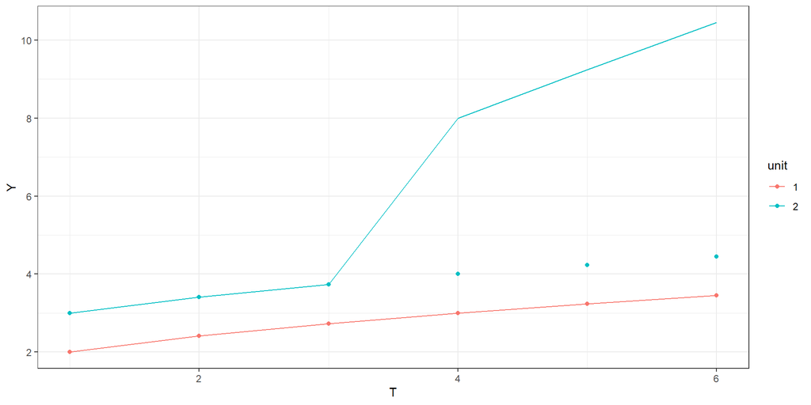

### 9.3.6 Extends to multiple units easily

```r
design |> redesign(n_units = 10) |> diagnose_design()
```

| Inquiry | Estimator | Bias |
| --- | --- | --- |
| ATE | FE1 | 2.25 |
| ATE | FE2 | 6.50 |
| ATE | FE3 | 1.50 |
| ATE | naive | 5.40 |
| ATT | FE1 | 0.75 |
| ATT | FE2 | 5.00 |
| ATT | FE3 | 0.00 |
| ATT | naive | 3.90 |

### 9.3.7 Extends to multipe units easily

```r
design |>
  redesign(n_units = 10) |>
  draw_data() |>
  ggplot(aes(T, Y, color = unit)) + geom_line() +
       geom_point(aes(T, Y_Z_0)) + theme_bw()
```

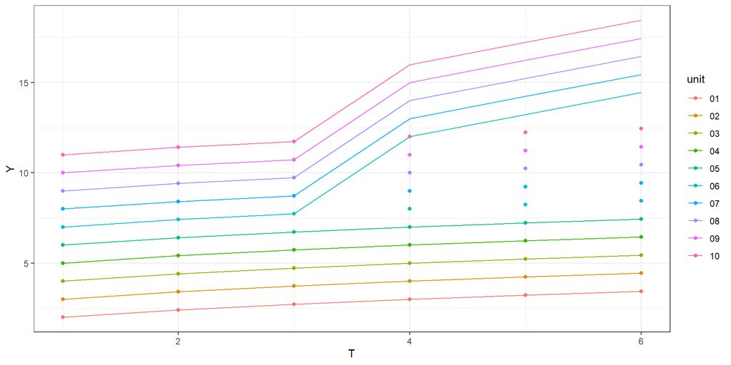

### 9.3.8 In practice

- Need to defend parallel trends
- Most typically using an *event study*
- Sometimes: report balance between treatment and control groups in covariates
- Placebo leads and lags

### 9.3.9 Heterogeneity

- Things get much more complicated when there is (a) heterogeneous timing in treatment take up and (b) heterogeneous effects
- It’s only recently been appreciated how tricky things can get
- But we already have an intuition from our analysis of trials with heterogeneous assignment and heterogeneous effects:
- in such cases fixed effects analysis weights stratum level treatment effects by the variance in assignment to treatment
- something similar here

### 9.3.10 Staggared assignments

Just two units assigned at different times:

```r
trend = 0

design <-
  declare_model(
    unit = add_level(N = 2, ui = rnorm(N), I = 1:N),
    time = add_level(N = 6, ut = rnorm(N), T = 1:N, nest = FALSE),
    obs = cross_levels(by = join_using(unit, time))) +
  declare_model(
    potential_outcomes(Y ~ trend*T + (1+Z)*(I == 2))) +
  declare_assignment(Z = 1*((I == 1) * (T>3) + (I == 2) * (T>5))) +
  declare_measurement(Y = reveal_outcomes(Y~Z),
                      I_c = I - mean(I)) +
  declare_inquiry(mean(Y_Z_1 - Y_Z_0)) +
  declare_estimator(Y ~ Z, label = "1. naive") +
  declare_estimator(Y ~ Z + I, label = "2. FE1") +
  declare_estimator(Y ~ Z + as.factor(T), label = "3. FE2") +
  declare_estimator(Y ~ Z + I + as.factor(T), label = "4. FE3") +
  declare_estimator(Y ~ Z*I_c + as.factor(T), label = "5. Sat")
```

### 9.3.11 Staggared assignments diagnosis

| Estimator | Mean Estimand | Mean Estimate |
| --- | --- | --- |
| 1. naive | 0.50 | -0.12 |
|  | (0.00) | (0.00) |
| 2. FE1 | 0.50 | 0.36 |
|  | (0.00) | (0.00) |
| 3. FE2 | 0.50 | -1.00 |
|  | (0.00) | (0.00) |
| 4. FE3 | 0.50 | 0.25 |
|  | (0.00) | (0.00) |
| 5. Sat | 0.50 | 0.50 |
|  | (0.00) | (0.00) |

### 9.3.12 Where do these numbers come?

- The estimand is .5 – this comes from weighting the effect for unit 1 (0) and the effect for unit 2 (1) equally
- The naive estimate is wildly off because it does not take into account that units with different treatment shares have different average levels in outcomes

### 9.3.13 Where do these numbers come?

- The estimate when we control for unit is 0.36: this comes from weighting the unit-stratum level effects according to the variance of assignment to each stratum:

```r
design |> draw_data() |> group_by(unit) |> summarize(var = mean(Z)*(1-mean(Z))) |>
  mutate(weight = var/sum(var)) |> kable(digits = 2)
```

| unit | var | weight |
| --- | --- | --- |
| 1 | 0.25 | 0.64 |
| 2 | 0.14 | 0.36 |

### 9.3.14 Where do these numbers come?

- The estimate when we control for time is -1: this comes from weighting the time-stratum level effects according to the variance of assignment to each stratum
- it weights periods 4 and 5 only and equally, yielding the difference in outcomes for unit 1 in treatment (0) and group 2 in control (1)

```r
design |> draw_data()  |> group_by(time) |> summarize(var = mean(Z)*(1-mean(Z))) |>
  mutate(weight = var/sum(var)) |> kable(digits = 2)
```

| time | var | weight |
| --- | --- | --- |
| 1 | 0.00 | 0.0 |
| 2 | 0.00 | 0.0 |
| 3 | 0.00 | 0.0 |
| 4 | 0.25 | 0.5 |
| 5 | 0.25 | 0.5 |
| 6 | 0.00 | 0.0 |

### 9.3.15 Where do these numbers come?

- The estimate when we control for time *and* unit is 0.25
- This is actually a lot harder to interpret:
- We can figure out what it is from the “Goodman-Bacon decomposition” in [Goodman-Bacon (2021)](https://www.nber.org/system/files/working_papers/w25018/w25018.pdf)

### 9.3.16 Where do these numbers come?

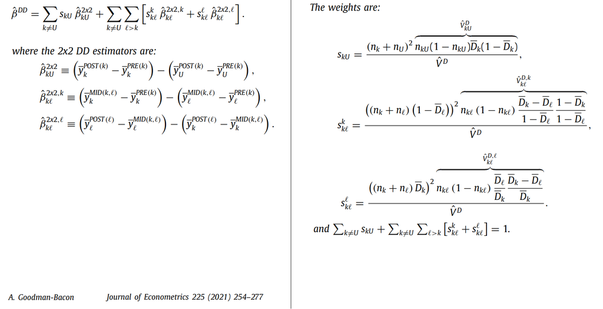

### 9.3.17 Where do these numbers come?

In this case we can think of our data having the following structure:

|  | y1 | y2 |
| --- | --- | --- |
| pre | 0 | 1 |
| mid | 0 | 1 |
| post | 0 | 2 |

- the mid to pre diff in diff is (0-0) - (1-1) = 0 (group 2 serves as control)
- the post to mid diff in diff is (2-1) - (0-0) = 1 (group 1 serves as control though already in treatment!)

TWFE gives a weighted average of these two, putting a 3/4 weight on the first and a 1/4 weight on the second

### 9.3.18 Two way fixed effects

Specifically:

$$\hat\beta^{DD} = \mu_{12}\hat\beta^{2 \times 2, 1}_{12} + (1-\mu_{12})\hat\beta^{2 \times 2, 2}_{12}$$

where $\mu_{12} = \frac{1-\overline{Z_1}}{1-(\overline{Z_1}-\overline{Z_2})} = \frac{1-\frac36}{1-\left(\frac36-\frac16\right)} = \frac34$

$$\frac34\hat\beta^{2 \times 2, 1}_{12} + \frac14 \hat\beta^{2 \times 2, 2}_{12}$$
(weights formula from [WP version](https://www.nber.org/system/files/working_papers/w25018/w25018.pdf))

### 9.3.19 Two way fixed effects

And:

- $\hat\beta^{2 \times 2, 1}_{12}$ is $(\overline{y}_1^{MID(1,2)} - \overline{y}_1^{PRE(1)}) - (\overline{y}_2^{MID(1,2)} - \overline{y}_2^{PRE(1)})$

which in the simple example without time trends is $(0 - 0) - (1-1) = 0$

- $\hat\beta^{2 \times 2, 2}_{12}$ is $(\overline{y}_2^{POST(2)} - \overline{y}_2^{MID(1,2)}) - (\overline{y}_1^{POST(2)} - \overline{y}_1^{MID(1,2)})$

which is $(2 - 1) - (0 - 0) = 1$

### 9.3.20 A problem

So *quite* complex weighting of different comparisons

- Units effectively get counted as both treatment and control units for different comparisons
- Treated units counted as control units
- Effectively negative weights on some quantities
- Possible to have very poorly performing estimates

### 9.3.21 Solutions

- Involve better specification of estimands
- Use of comparisons directly relevant for the estimands
- *Imputation* of control outcomes in treated units using data from appropriate control units only and then targetting estimands directly (Borusyak, Jaravel, and Spiess 2021)
- Particular solution: focus on the effect of treatment *at the time of first treatment* / or *time of switching*: this usually involves a no carryover assumption (De Chaisemartin and d’Haultfoeuille 2020) also Imai and Kim (2021)

### 9.3.22 Solutions

See excellent review by Roth et al. (2023)

```r
knitr::include_graphics("assets/didtools.jpg")
```

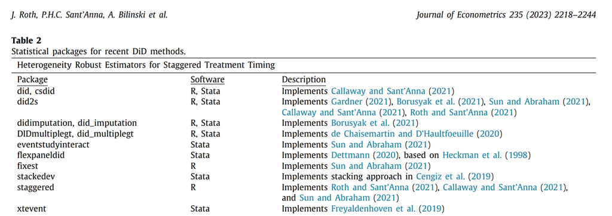

### 9.3.23 Chaisemartin and d’Haultfoeuille (2020).

```r
library(DIDmultiplegt)
library(rdss)
design <-
  declare_model(
    unit = add_level(N = 4, I = 1:N),
    time = add_level(N = 8, T = 1:N, nest = FALSE),
    obs = cross_levels(by = join_using(unit, time),
                       potential_outcomes(Y ~ T + (1 + Z)*I))) +
  declare_assignment(Z = 1*(T > (I + 4))) +
  declare_measurement(
    Y = reveal_outcomes(Y~Z),
    Z_lag = lag_by_group(Z, groups = unit, n = 1, order_by = T)) +
  declare_inquiry(
    ATT_switchers = mean(Y_Z_1 - Y_Z_0),
    subset = Z == 1 & Z_lag == 0 & !is.na(Z_lag)) +
  declare_estimator(
    Y = "Y",  G = "unit",  T = "T",  D = "Z",
    handler = label_estimator(rdss::did_multiplegt_tidy),
    inquiry = c("ATT_switchers"),
    label = "chaisemartin"
  )
```

### 9.3.24 Chaisemartin and d’Haultfoeuille (2020)

Note the inquiry

```r
run_design(design) |> kable(digits = 2)
```

| inquiry | estimand | estimator | estimate |
| --- | --- | --- | --- |
| ATT_switchers | 2 | chaisemartin | 2 |

### 9.3.25 Triple differencing

- A response to concerns that double differencing is not enough is to *triple* difference
- When you think that there may be a violation of parallel tends but you have other outcomes that would pick up the same *difference in trends*
- See Olden and Møen (2022)

### 9.3.26 Triple differencing

You are interested in the effects of influx of refugees on right wing voting

- You have (say more conservative) states with no refugees at any period
- You have (say more liberal) states with refugees post 2016 only

You want to do differences in differences comparing these states before and after

- However you worry that things change differntially in the conservative and liberal states: *no parallel trends*
- but you can identify areas *within* states that are more or less likely to be exposed and compare differnces in differences in the exposed and unexposed groups.

### 9.3.27 Triple differencing

So:

- Two types of states: $L \in \{0,1\}$, only $L=1$ types get refugee influx
- Two time periods: $Post \in \{0,1\}$, refugee influx occurs in period $Post = 1$
- Two groups: $B \in \{0,1\}$, $B=1$ types affected by refugee influx

$$Y = \beta_0 + \beta_1 L + \beta_2 B + \beta_3 Post + \beta_4 LB + \beta_5 L Post + \beta_6 B Post + \beta_7L B Post + \epsilon$$

### 9.3.28 Triple differencing

$$\frac{\partial ^3Y}{\partial L \partial B \partial Post} = \beta_7$$

### 9.3.29 Can we not just condition on the $B=1$ types?

The level among the $B=1$ types is:

$$Y = \beta_0 + \beta_1 L + \beta_2 + \beta_3 Post + \beta_4 L + \beta_5 L Post + \beta_6 Post + \beta_7L Post + \epsilon$$
If you did simple before / after differences among the $B$ types you would get

$$\Delta Y| L = 1, B = 1 = \beta_3 + \beta_5 + \beta_6 + \beta_7$$
$$\Delta Y| L = 0, B = 1 = \beta_3 + \beta_6$$

### 9.3.30 Can we not just condition on the $B=1$ types?

And so if you differenced again you would get:

$$\Delta^2 Y| B = 1 = \beta_5 + \beta_7$$
So the problem is that you have $\beta^5$ in here which corresponds exactly to how $L$ states change over time.

### 9.3.31 Triple

But we can figure out $\beta_5$ by doing a diff in diff among the $B$’s.

$$Y|B = 0 = \beta_0 + \beta_1 L + \beta_3 Post + \beta_5 L Post$$

$$\Delta^2 Y| B = 0 = \beta_5$$

### 9.3.32 Easier to swallow?

- The identifying assumption is that absent treatment the differences in trends between $L=0$ and $L=1$ would be the same for units with $B=0$ and $B=1$.
- See equation 5.4 in Olden and Møen (2022)

$$\left(E[Y_0|L=1, B=1, {\textit {Post}}=1] - E[Y_0|L=1, B=1, {\textit {Post}}=0]\right) \\
\quad - \ \left(E[Y_0|L=1, B=0, {\textit {Post}}=1] - E[Y_0|L=1, B=0, {\textit {Post}}=0]\right) \\
= \nonumber \\
\left(E[Y_0|L=0, B=1, {\textit {Post}}=1] - E[Y_0|L=0, B=1, {\textit {Post}}=0]\right) \\
\quad - \ \left(E[Y_0|L=0, B=0, {\textit {Post}}=1] - E[Y_0|L=0, B=0, {\textit {Post}}=0]\right)$$

### 9.3.33 Easier to swallow?

- In a sense this is *one* parallel trends assumption, not two
- But there are four counterfactual quantities in this expression.

**Puzzle**: Is it possible to have an effect identified by a difference in difference but incorrectly by a triple difference design?

## 9.4 Regression discontintuity

Errors and diagnostics

### 9.4.1 Intuition

- The core idea in an RDD design is that if a decision rule assigns units that are *almost identical* to each other to treatment and control conditions then we can infer effects *for those cases* by looking *at those cases*.

See excellent introduction: Lee and Lemieux (2010)

### 9.4.2 Intuition

- Kids born on 31 August start school a year younger than kids born on 1 September: does starting younger help or hurt?
- Kids born on 12 September 1983 are more likely to register Republican than kids born on 10 September 1983: can this identify the effects of registration on long term voting?
- A district in which Republicans got 50.1% of the vote get a Republican representative while districts in which Republicans got 49.9% of the vote do not: does having a Republican representative make a difference for these districts?

### 9.4.3 Argument for identification

Setting:

- Typically the decision is based on a value on a “running variable”, $X$. e.g. Treatment if $X > 0$
- The estimand is $\mathbb{E}[Y(1) - Y(0)|X=0]$

Two arguments:

1. Continuity: $\mathbb{E}[Y(1)|X=x]$ and $\mathbb{E}[Y(0)|X=x]$ are continuous (at $x=0$) in $x$: so $\lim_{\hat x \rightarrow 0}\mathbb{E}[Y(0)|X=\hat x] = \mathbb{E}[Y(0)|X=\hat 0]$
2. Local randomization: tiny things that determine exact values of $x$ are *as if* random and so we can think of a local experiment around $X=0$.

### 9.4.4 Argument for identification

Note:

- continuity argument requires continuous $x$: granularity
- also builds off a conditional expectation function defined at $X=0$

Exclusion restriction is *implicit* in continuity: If *something else* happens at the threshold then the conditional expectation functions jump at the thresholds

Implicit: $X$ is exogenous in the sense that units cannot adjust $X$ in order to be on one or the other side of the threshold

### 9.4.5 Evidence

Typically researchers show:

1. “First stage” results: assignment to treatment does indeed jump at the threshold
2. “ITT”: outcomes jump at the threshold
3. LATE (if fuzzy / imperfect compliance) using IV

### 9.4.6 Evidence

Typically researchers show:

In addition:

1. Arguments for no other treatments at the threshold
2. Arguments for no “sorting” at the threshold
3. Evidence for no “heaping” at the threshold (McCrary density test)

Sometimes:

- argue for why estimates extend beyond the threshold
- exclude points *at* the threshold (!)

### 9.4.7 Design

```r
library(rdss) # for helper functions
library(rdrobust)

cutoff <- 0.5
bandwidth <- 0.5

control <- function(X) {
  as.vector(poly(X, 4, raw = TRUE) %*% c(.7, -.8, .5, 1))}
treatment <- function(X) {
  as.vector(poly(X, 4, raw = TRUE) %*% c(0, -1.5, .5, .8)) + .25}

rdd_design <-
  declare_model(
    N = 1000,
    U = rnorm(N, 0, 0.1),
    X = runif(N, 0, 1) + U - cutoff,
    D = 1 * (X > 0),
    Y_D_0 = control(X) + U,
    Y_D_1 = treatment(X) + U
  ) +
  declare_inquiry(LATE = treatment(0) - control(0)) +
  declare_measurement(Y = reveal_outcomes(Y ~ D)) +
  declare_sampling(S = X > -bandwidth & X < bandwidth) +
  declare_estimator(Y ~ D*X, term = "D", label = "lm") +
  declare_estimator(
    Y, X,
    term = "Bias-Corrected",
    .method = rdrobust_helper,
    label = "optimal"
  )
```

### 9.4.8 RDD Data plotted

Note `rdrobust` implements:

- local polynomial Regression Discontinuity (RD) point estimators
- robust bias-corrected confidence intervals

See Calonico, Cattaneo, and Titiunik (2014) and related papers `? rdrobust::rdrobust`

### 9.4.9 RDD Data plotted

```r
rdd_design  |> draw_data() |> ggplot(aes(X, Y, color = factor(D))) +
  geom_point(alpha = .3) + theme_bw() +
  geom_smooth(aes(X, Y_D_0)) + geom_smooth(aes(X, Y_D_1)) + theme(legend.position = "none")
```

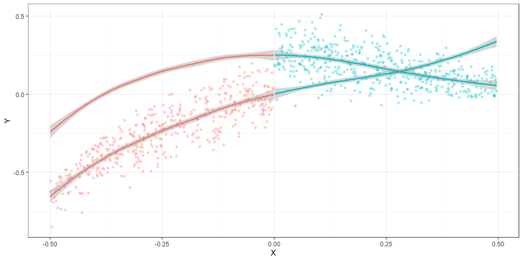

### 9.4.10 RDD diagnosis

```r
rdd_design |> diagnose_design()
```

| Estimator | Mean Estimate | Bias | SD Estimate | Coverage |
| --- | --- | --- | --- | --- |
| lm | 0.23 | -0.02 | 0.01 | 0.64 |
|  | (0.00) | (0.00) | (0.00) | (0.02) |
| optimal | 0.25 | 0.00 | 0.03 | 0.89 |
|  | (0.00) | (0.00) | (0.00) | (0.01) |

### 9.4.11 Bandwidth tradeoff

```r
rdd_design |>
  redesign(bandwidth = seq(from = 0.05, to = 0.5, by = 0.05)) |>
  diagnose_designs()
```

[figure not shown]

- As we increase the bandwidth, the lm bias gets worse, but slowly, while the error falls.
- The best bandwidth is relatively wide.
- This is more true for the optimal estimator.

### 9.4.12 Geographic RDs

Are popular in political science:

- Put a lot of pressure on assumption of no alternative treatment—including “random” country level shocks!
- Put a lot of pressure on no sorting assumptions (why was the border put where it was; why did units settle here or there?)
- Put a lot of pressure on SUTVA: people on one side are literally proximate to people on another

See Keele and Titiunik (2015)

## 9.5 Spillovers

### 9.5.1 SUTVA violations (Spillovers)

Spillovers can result in the estimation of weaker effects when effects are actually stronger.

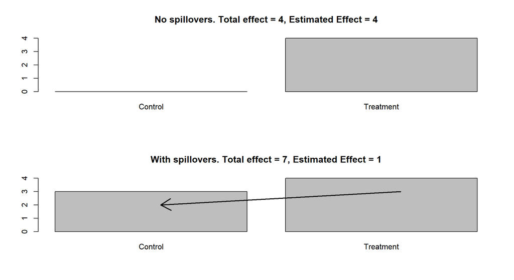

The key problem is that $Y(1)$ and $Y(0)$ are not sufficient to describe potential outcomes

### 9.5.2 SUTVA violations

| Unit | Location | $D_\emptyset$ | $y(D_\emptyset)$ | $D_1$ | $y(D_1)$ | $D_2$ | $y(D_2)$ | $D_3$ | $y(D_3)$ | $D_4$ | $y(D_4)$ |
| --- | --- | --- | --- | --- | --- | --- | --- | --- | --- | --- | --- |
| A | 1 | 0 | 0 | 1 | 3 | 0 | 1 | 0 | 0 | 0 | 0 |
| B | 2 | 0 | 0 | 0 | 3 | 1 | 3 | 0 | 3 | 0 | 0 |
| C | 3 | 0 | 0 | 0 | 0 | 0 | 3 | 1 | 3 | 0 | 3 |
| D | 4 | 0 | 0 | 0 | 0 | 0 | 0 | 0 | 1 | 1 | 3 |

*Table: Potential outcomes for four units for different treatment profiles*. $D_i$ is an allocation and $y_j(D_i)$ is the potential outcome for (row) unit $j$ given (column) $D_i$.

- The key is to think through the structure of spillovers.
- Here immediate neighbors are exposed
- In this case we can **define a direct treatment** (being exposed) and **an indirect treatment** (having a neighbor exposed) and we can work out *the* *propensity* *for each unit of receiving each type of treatment*
- These may be non uniform (here central types are more likely to have teated neighbors); but we can still use the randomization to assess effects

### 9.5.3 SUTVA violations

|  |  |  | **0** |  | **1** |  | **2** |  | **3** |  | **4** |
| --- | --- | --- | --- | --- | --- | --- | --- | --- | --- | --- | --- |
| Unit | Location | $D_\emptyset$ | $y(D_\emptyset)$ | $D_1$ | $y(D_1)$ | $D_2$ | $y(D_2)$ | $D_3$ | $y(D_3)$ | $D_4$ | $y(D_4)$ |
| A | 1 | 0 | 0 | 1 | 3 | 0 | 1 | 0 | 0 | 0 | 0 |
| B | 2 | 0 | 0 | 0 | 3 | 1 | 3 | 0 | 3 | 0 | 0 |
| C | 3 | 0 | 0 | 0 | 0 | 0 | 3 | 1 | 3 | 0 | 3 |
| D | 4 | 0 | 0 | 0 | 0 | 0 | 0 | 0 | 1 | 1 | 3 |
| $\bar{y}_\text{treated}$ |  |  | - |  |  | 3 |  | 3 |  | 3 |  |
| $\bar{y}_\text{untreated}$ |  |  | 0 |  |  | 1 |  | 4/3 |  | 4/3 |  |
| $\bar{y}_\text{neighbors}$ |  |  | - |  |  | 3 |  | 2 |  | 2 |  |
| $\bar{y}_\text{pure control}$ |  |  | 0 |  |  | 0 |  | 0 |  | 0 |  |
| *ATT-direct* |  |  | - |  |  | 3 |  | 3 |  | 3 |  |
| *ATT-indirect* |  |  | - |  |  | 3 |  | 2 |  | 2 |  |

### 9.5.4 Design

```r
dgp <- function(i, Z, G) Z[i]/3 + sum(Z[G == G[i]])^2/5 + rnorm(1)

spillover_design <-

  declare_model(G = add_level(N = 80),
                     j = add_level(N = 3, zeros = 0, ones = 1)) +

  declare_inquiry(direct = mean(sapply(1:240,  # just i treated v no one treated
    function(i) { Z_i <- (1:240) == i
                  dgp(i, Z_i, G) - dgp(i, zeros, G)}))) +

  declare_inquiry(indirect = mean(sapply(1:240,
    function(i) { Z_i <- (1:240) == i           # all but i treated v no one treated
                  dgp(i, ones - Z_i, G) - dgp(i, zeros, G)}))) +

  declare_assignment(Z = complete_ra(N)) +

  declare_measurement(
    neighbors_treated = sapply(1:N, function(i) sum(Z[-i][G[-i] == G[i]])),
    one_neighbor  = as.numeric(neighbors_treated == 1),
    two_neighbors = as.numeric(neighbors_treated == 2),
    Y = sapply(1:N, function(i) dgp(i, Z, G))
  ) +

  declare_estimator(Y ~ Z,
                    inquiry = "direct",
                    model = lm_robust,
                    label = "naive") +

  declare_estimator(Y ~ Z * one_neighbor + Z * two_neighbors,
                    term = c("Z", "two_neighbors"),
                    inquiry = c("direct", "indirect"),
                    label = "saturated",
                    model = lm_robust)
```

### 9.5.5 Spillovers: direct and indirect treatments

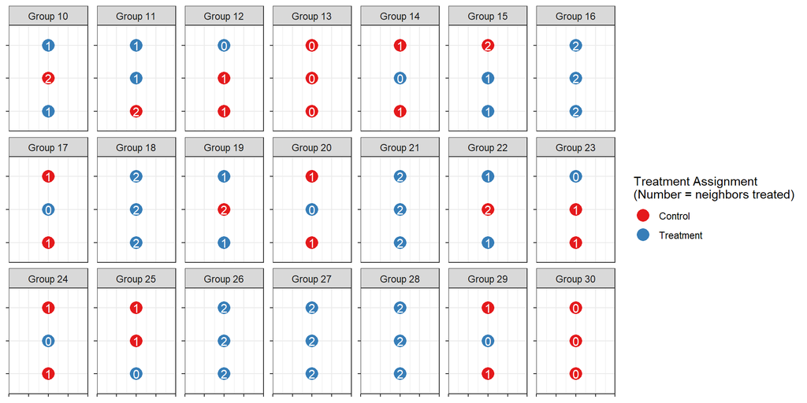

### 9.5.6 Spillovers: Simulated estimates

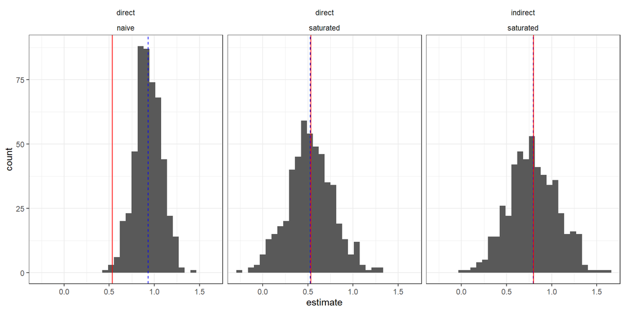

### 9.5.7 Spillovers: Opportunities and Warnings

You can in principle:

- debias estimates
- learn about interesting processes
- optimize design parameters

But to estimate effects you still need *some* SUTVA like assumption.

### 9.5.8 Spillovers: Opportunities and Warnings

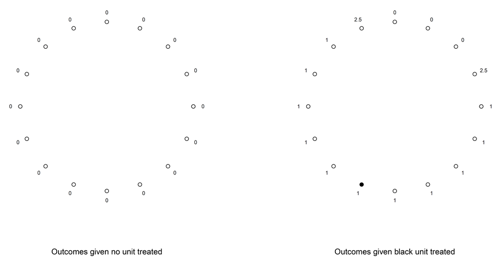

In this example if one compared the outcome between treated units and all control units that are at least $n$ positions away from a treated unit you will get the wrong answer unless $n \geq 7$.

## 9.6 Mediation

### 9.6.1 The problem of unidentified mediators

- Consider a causal system like the below.
- The effect of X on M1 and M2 can be measured in the usual way.
- But unfortunately, if there are multiple mediators, the effect of M1 (or M2) on Y is not identified.
- The ‘exclusion restriction’ is obviously violated when there are multiple mediators (unless you can account for them all).

### 9.6.2 The problem of unidentified mediators

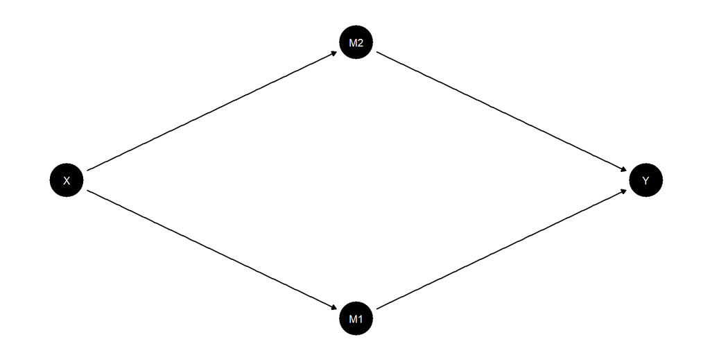

Which effects are identified by the random assignment of $X$?

### 9.6.3 The problem of unidentified mediators

An obvious approach is to first examine the (average) effect of X on M1 and then use another manipulation to examine the (average) effect of M1 on Y.

- But **both of these average effects may be positive (for example) even if there is no effect of X on Y through M1**.

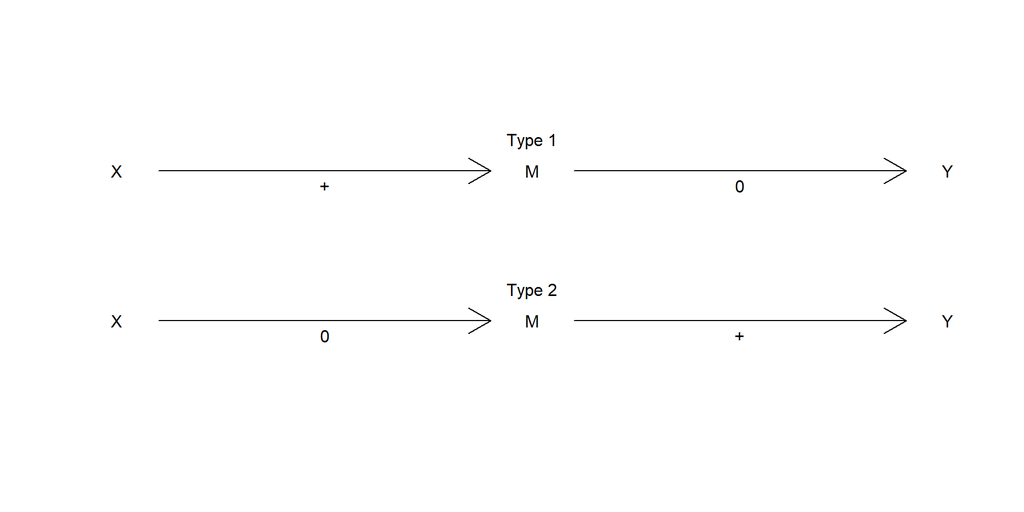

### 9.6.4 The problem of unidentified mediators

An obvious approach is to first examine the (average) effect of X on M1 and then use another manipulation to examine the (average) effect of M1 on Y.

- Similarly **both of these average effects may be zero even if X affects on Y through M1 for every unit!**

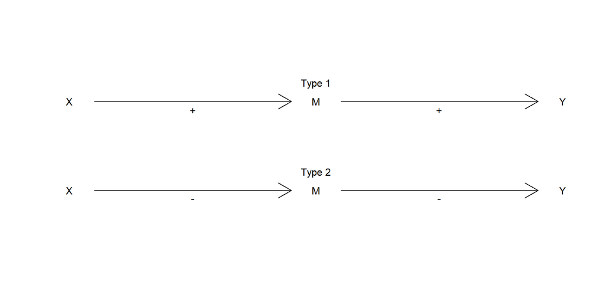

### 9.6.5 The problem of unidentified mediators

Both instances of unobserved confounding between $M$ and $Y$:

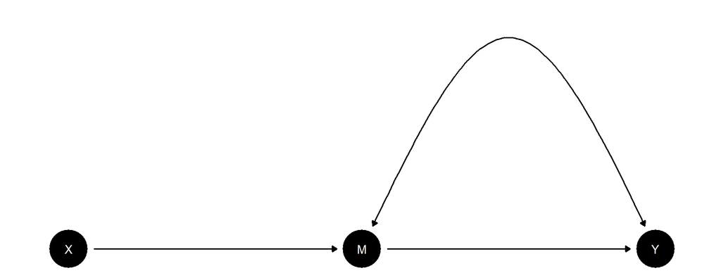

### 9.6.6 The problem of unidentified mediators

Both instances of unobserved confounding between $M$ and $Y$:

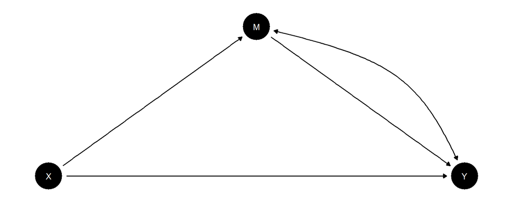

### 9.6.7 The problem of unidentified mediators

- Another somewhat obvious approach is to see how the effect of $X$ on $Y$ in a regression is reduced when you control for $M$.
- If the effect of $X$ on $Y$ passes through $M$ then surely there should be no effect of $X$ on $Y$ after you control for $M$.
- This common strategy associated with Baron and Kenny (1986) is also not guaranteed to produce reliable results. See for instance Green, Ha, and Bullock (2010)

### 9.6.8 Baron Kenny issues

```r
df <- fabricate(N = 1000,
                U = rbinom(N, 1, .5),     X = rbinom(N, 1, .5),
                M = ifelse(U==1, X, 1-X), Y = ifelse(U==1, M, 1-M))

list(lm(Y ~ X, data = df),
     lm(Y ~ X + M, data = df)) |> texreg::htmlreg()
```

Statistical models

|  | Model 1 | Model 2 |
| --- | --- | --- |
| (Intercept) | 0.00*** | 0.00*** |
|  | (0.00) | (0.00) |
| X | 1.00*** | 1.00*** |
|  | (0.00) | (0.00) |
| M |  | 0.00 |
|  |  | (0.00) |
| R<sup>2</sup> | 1.00 | 1.00 |
| Adj. R<sup>2</sup> | 1.00 | 1.00 |
| Num. obs. | 1000 | 1000 |

***p < 0.001; **p < 0.01; *p < 0.05

### 9.6.9 The problem of unidentified mediators

- See [Imai](http://imai.princeton.edu/projects/mechanisms.html) on better ways to think about this problem and designs to address it.

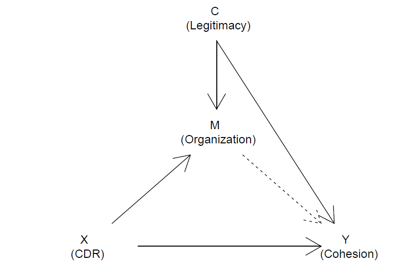

### 9.6.10 The problem of unidentified mediators: Quantities

- Using potential outcomeswe can describe a **mediation effect** as (see Imai et al):
  $$\delta_i(t) = Y_i(t, M_i(1)) - Y_i(t, M_i(0)) \textbf{ for } t = 0,1$$
- The **direct effect** is:
  $$\psi_i(t) = Y_i(1, M_i(t)) - Y_i(0, M_i(t)) \textbf{ for } t = 0,1$$
- This is a **decomposition**, since:
  $$Y_i(1, M_i(1)) - Y_1(0, M_i(0)) = \frac{1}{2}(\delta_i(1) + \delta_i(0) + \psi_i(1) + \psi_i(0))$$
- If there are no interaction effects—ie $\delta_i(1) = \delta_i(0), \psi_i(1) = \psi_i(0)$, then
  $$Y_i(1, M_i(1)) - Y_1(0, M_i(0)) = \delta_i + \psi_i$$

### 9.6.11 The problem of unidentified mediators: Solutions?

The bad news is that although a single experiment might identify the total effect, it can not identify these elements of the direct effect.

So:

- Check **formal requirement** for identification under single experiment design (“sequential ignorability”—that, conditional on actual treatment, it is as if the value of the mediation variable is randomly assigned relative to potential outcomes). But this is strong (and in fact unverifiable) and if it does not hold, bounds on effects always include zero (Imai et al)
- Consider sensitivity analyses

### 9.6.12 **Implicit mediation**

You can use **interactions** with covariates **if you are willing to make assumptions on no heterogeneity of direct treatment effects** over covariates.

eg you think that money makes people get to work faster because they can buy better cars; you look at the marginal effect of more money on time to work for people with and without cars and find it higher for the latter.

This might imply mediation through transport but only if there is no direct effect heterogeneity (eg people with cars are less motivated by money).

### 9.6.13 The problem of unidentified mediators: Solutions?

Weaker assumptions justify **parallel design**

- Group A: $T$ is randomly assigned, $M$ left free.
- Group B: divided into four groups $T\times M$ (requires two more assumptions (1) that the **manipulation** of the mediator only affects outcomes through the mediator (2) **no interaction**, for each unit, $Y(1,m)-Y(0,m) = Y(1,m')-Y(0,m')$.)

**Takeaway**: Understanding mechanisms is harder than you think. Figure out what assumptions fly.

### 9.6.14 In `CausalQueries`

Lets imagine that sequential ignorability does not hold. What are our posteriors on mediation quantities when in fact all effects are mediated, effects are strong, and we have lots of data?

```r
model <- make_model("X -> M ->Y <- X; M <-> Y")

plot(model)
```

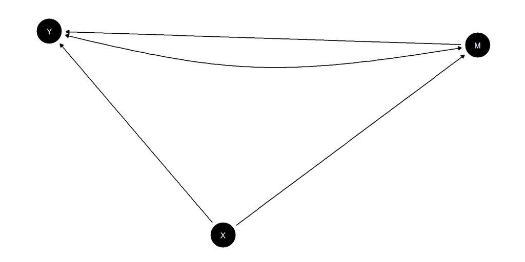

### 9.6.15 In `CausalQueries`

We imagine a true model and consider estimands:

```r
truth <- make_model("X -> M ->Y") |>
  set_parameters(c(.5, .5, .1, 0, .8, .1, .1, 0, .8, .1))

queries  <-
  list(
      indirect = "Y[X = 1, M = M[X=1]] - Y[X = 1, M = M[X=0]]",
      direct = "Y[X = 1, M = M[X=0]] - Y[X = 0, M = M[X=0]]"
      )

truth |> query_model(queries) |> kable()
```

| query | given | using | case_level | mean | sd | cred.low | cred.high |
| --- | --- | --- | --- | --- | --- | --- | --- |
| indirect | - | parameters | FALSE | 0.64 | NA | 0.64 | 0.64 |
| direct | - | parameters | FALSE | 0.00 | NA | 0.00 | 0.00 |

### 9.6.16 In `CausalQueries`

```r
model |> update_model(data = truth |> make_data(n = 1000)) |>
  query_distribution(queries = queries, using = "posteriors")
```

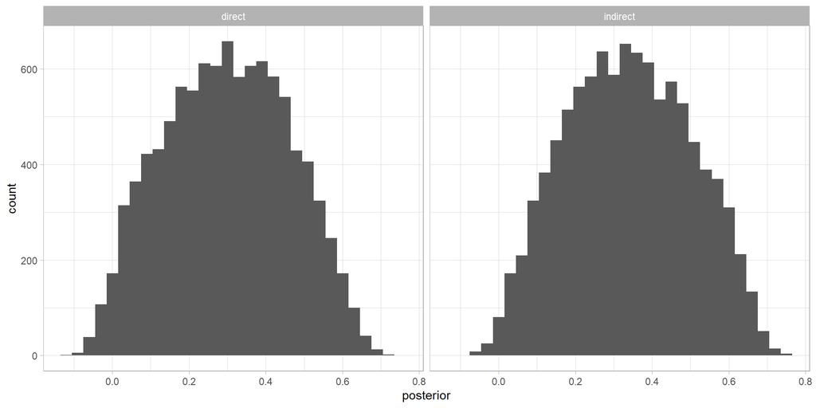

Why such poor behavior? Why isn’t weight going onto indirect effects?

Turns out the data *is* consistent with direct effects only: specifically that whenever $M$ is responsive to $X$, $Y$ is responsive to $X$.

### 9.6.17 In `CausalQueries`

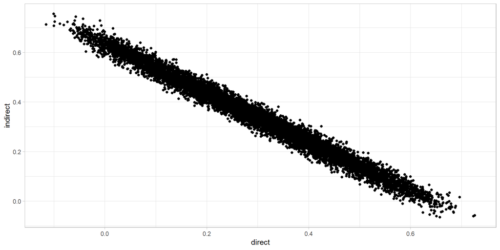